# Data605 - Final Exam

# 0. Load libraries and initialize things

```r
rm(list = ls())
library(tidyverse)
library(tidymodels)
library(skimr)
library(keras)
library(ggplot2)
library(matrixcalc)
library(pracma)
```

# 1. Playing with PageRank

## 1.1 - Form the A matrix. Then, introduce decay and form the B matrix as we did in the course notes.

```r
#Create a transitions Matrix A
options(digits = 3)

r1 <- c(0,1/2,1/2,0,0,0)
r2 <- c(0,0,0,0,0,0)
r3 <- c(1/3,1/3,0,0,1/3,0)
r4 <- c(0,0,0,0,1/2,1/2)
r5 <- c(0,0,0,1/2,0,1/2)
r6 <- c(0,0,0,1,0,0)

n =6

A <- matrix(c(r1,r2,r3,r4,r5,r6),n,n,byrow = TRUE)
r <- c(1/6,1/6,1/6,1/6,1/6,1/6)

print(A)
```

```
##       [,1]  [,2] [,3] [,4]  [,5] [,6]
## [1,] 0.000 0.500  0.5  0.0 0.000  0.0
## [2,] 0.000 0.000  0.0  0.0 0.000  0.0
## [3,] 0.333 0.333  0.0  0.0 0.333  0.0
## [4,] 0.000 0.000  0.0  0.0 0.500  0.5
## [5,] 0.000 0.000  0.0  0.5 0.000  0.5
## [6,] 0.000 0.000  0.0  1.0 0.000  0.0
```

```r
print(rowSums(A))
```

```
## [1] 1 0 1 1 1 1
```

We can see that Matrix A is not **row stochastic**. That means its row sums are not equal to one. In order to continue we need to make sure all rows are stochastic. So we will replace row 2 with a new row where all entries are 1/6 for equal probability and ensuring its sum = 1

```r
r2 <- c(1/6,1/6,1/6,1/6,1/6,1/6)

A <- matrix(c(r1,r2,r3,r4,r5,r6),n,n,byrow = TRUE)
print(A)
```

```
##       [,1]  [,2]  [,3]  [,4]  [,5]  [,6]
## [1,] 0.000 0.500 0.500 0.000 0.000 0.000
## [2,] 0.167 0.167 0.167 0.167 0.167 0.167
## [3,] 0.333 0.333 0.000 0.000 0.333 0.000
## [4,] 0.000 0.000 0.000 0.000 0.500 0.500
## [5,] 0.000 0.000 0.000 0.500 0.000 0.500
## [6,] 0.000 0.000 0.000 1.000 0.000 0.000
```

```r
print(rowSums(A))
```

```
## [1] 1 1 1 1 1 1
```

Lets define **B matrix**

```r
# Decay Factor
d <- 0.85

# Adjusted B matrix
B <- d * A + ((1-d)/n)
print(B)
```

```
##       [,1]  [,2]  [,3]  [,4]  [,5]  [,6]
## [1,] 0.025 0.450 0.450 0.025 0.025 0.025
## [2,] 0.167 0.167 0.167 0.167 0.167 0.167
## [3,] 0.308 0.308 0.025 0.025 0.308 0.025
## [4,] 0.025 0.025 0.025 0.025 0.450 0.450
## [5,] 0.025 0.025 0.025 0.450 0.025 0.450
## [6,] 0.025 0.025 0.025 0.875 0.025 0.025
```

Let’s check it is **row stochastic**

```r
print(rowSums(B))
```

```
## [1] 1 1 1 1 1 1
```

## 1.2 Start with a uniform rank vector **r** and perform power iterations on B until convergence. That is, compute the solution r = B^n * r. Attempt this for a sufficiently large n so that r actually converges.

```r
# Lets calculate a large number of steps to check convergence
nsteps = 100

#Make sure you use the transpose of A, since you want the FROM as columns, and as defined in the question the A matrix has the FROM as rows.

rf <- matrix.power(t(B),nsteps) %*% r

print(rf)
```

```
##            [,1]
## [1,] 0.05170475
## [2,] 0.07367926
## [3,] 0.05741241
## [4,] 0.34870369
## [5,] 0.19990381
## [6,] 0.26859608
```

```r
# Just to make sure it converged, compare to nsteps +1
rf <- matrix.power(t(B),nsteps+1) %*% r

print(rf)
```

```
##            [,1]
## [1,] 0.05170475
## [2,] 0.07367926
## [3,] 0.05741241
## [4,] 0.34870369
## [5,] 0.19990381
## [6,] 0.26859608
```

```r
# Yes. same vector it has converged!
```

We have a new vector **rf** which we also checked it converged to an answer. This is our **pagerank** vector answer!.

## 1.3 Compute the eigen-decomposition of B and verify that you indeed get an eigenvalue of 1 as the largest eigenvalue and that its corresponding eigenvector is the same vector that you obtained in the previous power iteration method.

So if you went ahead and just used the **eigen** function in R, you may not get the answer you expected.

```r
eigen(B)$values
```

```
## [1]  1.00000000  0.57619235 -0.42500001 -0.42499999 -0.34991524 -0.08461044
```

```r
# Largest eigen value = 1

eigen(t(B))$vectors
```

```
##              [,1]          [,2]                      [,3]
## [1,] 0.1044385+0i  0.2931457+0i  2.486934e-15+0.0000e+00i
## [2,] 0.1488249+0i  0.5093703+0i -8.528385e-16-6.9832e-23i
## [3,] 0.1159674+0i  0.3414619+0i -1.930646e-15-0.0000e+00i
## [4,] 0.7043472+0i -0.5890805+0i -7.071068e-01+0.0000e+00i
## [5,] 0.4037861+0i -0.1413606+0i  7.071068e-01+0.0000e+00i
## [6,] 0.5425377+0i -0.4135367+0i  0.000000e+00-1.7058e-08i
##                           [,4]           [,5]            [,6]
## [1,]  2.486934e-15-0.0000e+00i -0.06471710+0i -0.212296003+0i
## [2,] -8.528385e-16+6.9832e-23i  0.01388698+0i  0.854071294+0i
## [3,] -1.930646e-15+0.0000e+00i  0.07298180+0i -0.363638739+0i
## [4,] -7.071068e-01+0.0000e+00i -0.66058664+0i  0.018399984+0i
## [5,]  7.071068e-01-0.0000e+00i  0.73761812+0i -0.304719509+0i
## [6,]  0.000000e+00+1.7058e-08i -0.09918316+0i  0.008182973+0i
```

**To get same pagerank vector as what we got before by raising the Matrix to a large power, we will find instead the null space of the B matrix minus the Identity matrix.**

```r
#Fist we transpose and subtract the diagonal matrix. This is the same process we would follow to find Eigenvectors manually.

Bt <- t(B) - diag(n)
```

Now we have a new Matrix which we can solve for its **null space**. We will use **pracma** library for this. The answer would be a multiple of the final answer we want.

```r
#Find the null space of the transformed B matrix
pracmaBnull <- pracma::nullspace(Bt)

# Lets find a factor between the nullspace of B and the PageRank vector.  One should be a multiple of the other

lambdaFactor <- pracmaBnull[1,1] / rf[1,1]
rf * lambdaFactor
```

```
##           [,1]
## [1,] 0.1044385
## [2,] 0.1488249
## [3,] 0.1159674
## [4,] 0.7043472
## [5,] 0.4037861
## [6,] 0.5425377
```

```r
pracmaBnull
```

```
##           [,1]
## [1,] 0.1044385
## [2,] 0.1488249
## [3,] 0.1159674
## [4,] 0.7043472
## [5,] 0.4037861
## [6,] 0.5425377
```

**Solved**. We can see now, that the null space of B transformed is the **same Eigenvector** as the **PageRank** vector, just with a different scaling factor, but none the less same vector.

We just showed that our **EIGENVECTOR** for Lambda equal to 1 is the **SAME** as the pagerank vector we found earlier.

## 1.4 Use the graph package in R and its page.rank method to compute the Page Rank of the graph as given in A.

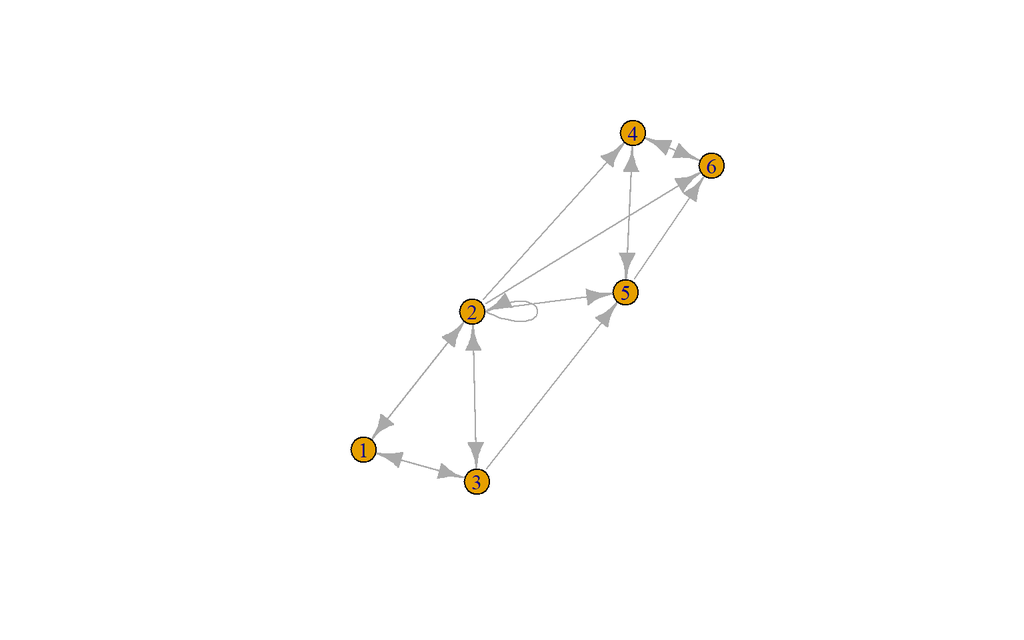

```r
#library Graph no longer exists in CRAN. But I found another library to do the trick

library(igraph)

A_Graph <- graph_from_adjacency_matrix(A, weighted = TRUE, mode = "directed")
plot(A_Graph)
```

Let’s see that library’s **pagerank** result.

```r
pageRank <- page.rank(A_Graph)$vector
```

All 3 methods give **same answer**

```r
# Pagerank vector by taking Matrix powers until convergence
print(t(rf))
```

```
##            [,1]       [,2]       [,3]      [,4]      [,5]      [,6]
## [1,] 0.05170475 0.07367926 0.05741241 0.3487037 0.1999038 0.2685961
```

```r
# Pagerank vector by doing spectral decomposition of the B matrix
print(t(pracmaBnull/lambdaFactor))
```

```
##            [,1]       [,2]       [,3]      [,4]      [,5]      [,6]
## [1,] 0.05170475 0.07367926 0.05741241 0.3487037 0.1999038 0.2685961
```

```r
# Page rank of matrix A by using page.rank function
print(pageRank)
```

```
## [1] 0.05170475 0.07367926 0.05741241 0.34870369 0.19990381 0.26859608
```

# 2. MNIST Dataset

## 2.1 Load files and Plot function

```r
#setwd("Code/FinalExam/MNIST")
train_df <- read_csv("MNIST/train.csv")
test_df <- read_csv('MNIST/test.csv')
train_df[,2:ncol(train_df)] <- train_df[,2:ncol(train_df)] / 255
head(train_df)
```

```
## # A tibble: 6 x 785
##   label pixel0 pixel1 pixel2 pixel3 pixel4 pixel5 pixel6 pixel7 pixel8 pixel9
##   <dbl>  <dbl>  <dbl>  <dbl>  <dbl>  <dbl>  <dbl>  <dbl>  <dbl>  <dbl>  <dbl>
## 1     1      0      0      0      0      0      0      0      0      0      0
## 2     0      0      0      0      0      0      0      0      0      0      0
## 3     1      0      0      0      0      0      0      0      0      0      0
## 4     4      0      0      0      0      0      0      0      0      0      0
## 5     0      0      0      0      0      0      0      0      0      0      0
## 6     0      0      0      0      0      0      0      0      0      0      0
## # ... with 774 more variables: pixel10 <dbl>, pixel11 <dbl>, pixel12 <dbl>,
## #   pixel13 <dbl>, pixel14 <dbl>, pixel15 <dbl>, pixel16 <dbl>, pixel17 <dbl>,
## #   pixel18 <dbl>, pixel19 <dbl>, pixel20 <dbl>, pixel21 <dbl>, pixel22 <dbl>,
## #   pixel23 <dbl>, pixel24 <dbl>, pixel25 <dbl>, pixel26 <dbl>, pixel27 <dbl>,
## #   pixel28 <dbl>, pixel29 <dbl>, pixel30 <dbl>, pixel31 <dbl>, pixel32 <dbl>,
## #   pixel33 <dbl>, pixel34 <dbl>, pixel35 <dbl>, pixel36 <dbl>, pixel37 <dbl>,
## #   pixel38 <dbl>, pixel39 <dbl>, pixel40 <dbl>, pixel41 <dbl>, ...
```

Let’s create a basic function that would take the matrix information of the MNIST digits and display it on screen.

```r
#Function to display DIGITS

disp_digit <- function(digit_row, d_label) {

  img1 <- matrix(unlist(digit_row),nrow=28,ncol=28,byrow=TRUE)

  # reverse and transpose, if not image rotated 90 degrees
  img1 <- t(apply(img1, 2, rev))

  # To keep aspect ratio
  par(pty="s")

  image(1:28, 1:28, img1, col=gray((0:255)/255),
        axes=FALSE, xlab = d_label, ylab = "")

}
```

Let’s test the function displaying the 10th row in our dataset

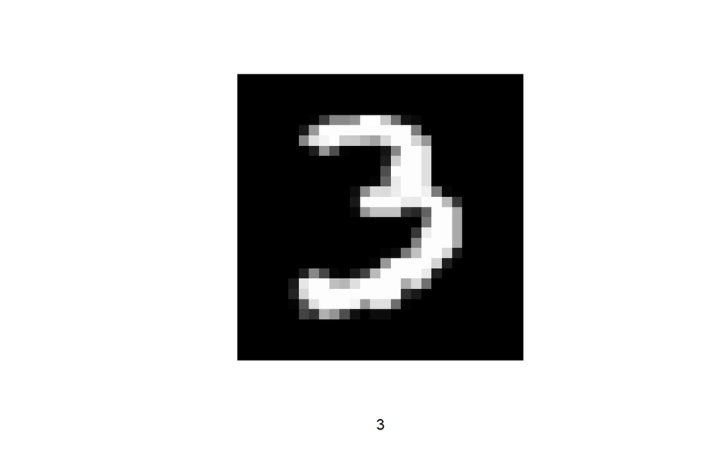

```r
# Choose a row (digit image)
idnum=10
disp_digit(train_df[idnum,2:ncol(train_df)], train_df[idnum,1])
```

We should be looking at a number “3”

## 2.2 Basic information about dataset

**Display the frequency of each number in the dataset**

```r
# count of all rows by Label (digit)
train_df %>%
  group_by(label) %>%
  summarise(Count = n()) %>%
  mutate(frequency = Count / sum(Count))
```

```
## # A tibble: 10 x 3
##    label Count frequency
##    <dbl> <int>     <dbl>
##  1     0  4132    0.0984
##  2     1  4684    0.112
##  3     2  4177    0.0995
##  4     3  4351    0.104
##  5     4  4072    0.0970
##  6     5  3795    0.0904
##  7     6  4137    0.0985
##  8     7  4401    0.105
##  9     8  4063    0.0967
## 10     9  4188    0.0997
```

We can see here that although not exact, each digit 0 to 9 is represented almost uniformly across the dataset.

Just a few queries we may need later.

```r
# 10 Rows, one per digit withe sum of every pixel (784)
train_sum_df <- train_df %>%
  group_by(label) %>%
  summarise(across(everything(),sum), .groups = 'drop')
```

```r
# 10 Rows, with sum of all columns
train_sum_columns <- train_df %>%
  group_by(label) %>%
  summarise(across(everything(),sum), .groups = 'drop') %>%
  summarise(label=label,pixel_sum = rowSums(.))
```

```r
# 10 Rows, one per digit with the mean of every pixel (784)
# this just tell us for each digit, what is the mean of every specific pixel.

train_mean_df <- train_df %>%
  group_by(label) %>%
  summarise(across(everything(),mean), .groups = 'drop')
```

## 2.3 Plot some numbers

Let’s plot the first ten numbers in the dataframe

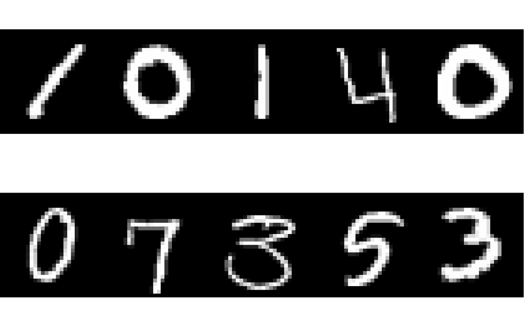

```r
# Plot First 10 numbers on dataframe
par(mfrow=c(2,5),mai = c(0.1, 0.1, 0.1, 0.1),mar=c(1, 0, 1, 0))

for (i in 1:10) {
  disp_digit(train_df[i,2:ncol(train_df)],"")

}
```

For fun let’s **average all rows grouped by number and display it.

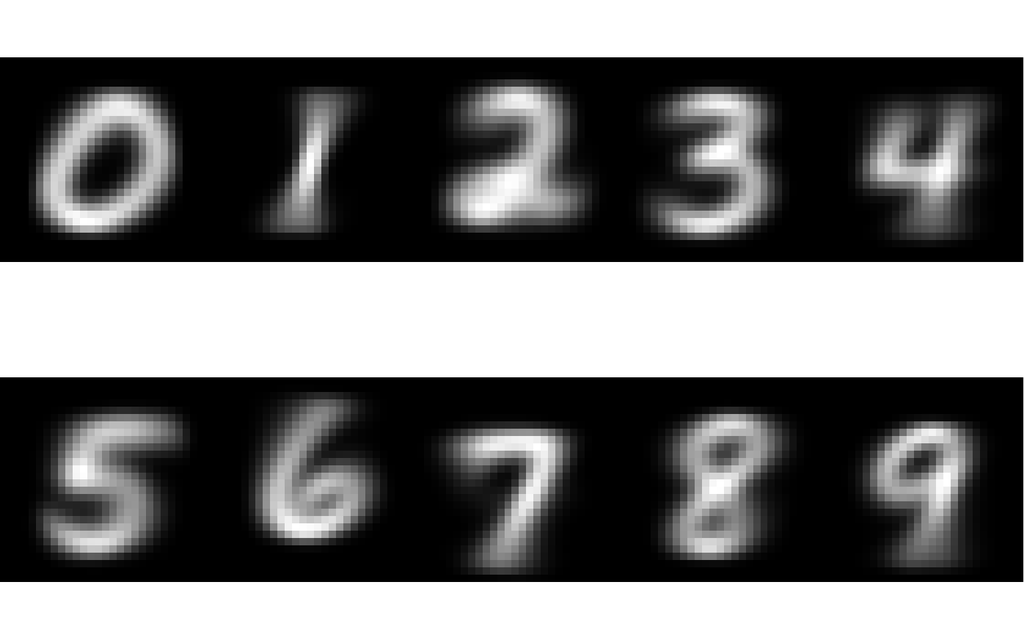

```r
# Plot all 10 digits based on averages
par(mfrow=c(2,5),mai = c(0.1, 0.1, 0.1, 0.1),mar=c(1, 0, 1, 0))
for (i in 1:10) {
  #disp_digit(train_mean_df[i,2:ncol(train_mean_df)])
  disp_digit(train_mean_df[i,2:ncol(train_mean_df)],"")
}
```

## 2.4 More info about dataset

**Display the mean of pixels for every digit. This average would be equivalent to the amount of “white” color each digit has. You can see that in where number 1 has a lower mean than number 8.**

```r
# Mean pixel intensity by digit
train_df %>%
  group_by(label) %>%
  summarise(across(everything(),sum), .groups = 'drop', count=n()) %>%
  summarise(label=label,pixel_sum = rowSums(.), count = count, avg_pix = pixel_sum/count/784)
```

```
## # A tibble: 10 x 4
##    label pixel_sum count avg_pix
##    <dbl>     <dbl> <int>   <dbl>
##  1     0   565313.  4132  0.175
##  2     1   283676.  4684  0.0772
##  3     2   493479.  4177  0.151
##  4     3   487574.  4351  0.143
##  5     4   391039.  4072  0.122
##  6     5   388299.  3795  0.131
##  7     6   454101.  4137  0.140
##  8     7   400174.  4401  0.116
##  9     8   485005.  4063  0.152
## 10     9   407456.  4188  0.124
```

## 2.5 PCA (Principal Component Analysis)

```r
# Call PCA for all numbers to the max 744 principal components)

pca_result <- prcomp(train_df[,2:ncol(train_df)], rank = 784, center=TRUE)
#summary(pca_result)
```

The maximum Principal components, is the minimum of the number of columns or number of rows. In this case we can get up to **784** principal components, although you may not need need most of them. The idea is that you will be able to capture most of the information in the dataset with a smaller subset of the overall information. This can help save space and accelerate processing time.

**Check variance by principal component**

```r
# std deviation
sdev <- pca_result$sdev
percent_variation <- sdev^2 / sum(sdev^2)

var_df <- data.frame(PC=paste0("PC",1:length(sdev)),
                     var_explained=percent_variation,
                     stringsAsFactors = FALSE)
```

**Let’s do some plotting.**

```r
# Function which will help later plot all PC's
every_nth = function(n) {
  return(function(x) {x[c(TRUE, rep(FALSE, n - 1))]})
}
```

Plot of the variance explained by each Principal Component

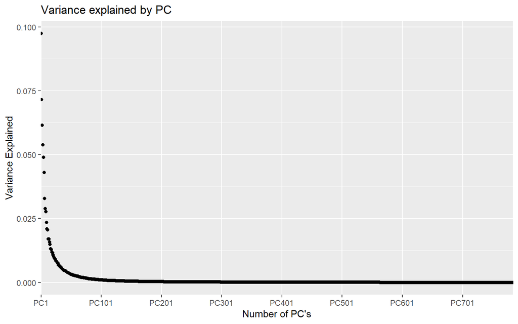

```r
var_df %>%
  mutate(PC = fct_inorder(PC)) %>%
  ggplot(aes(x=PC,y=var_explained))+
  scale_x_discrete(breaks=every_nth(n=100)) +
  geom_point() + ggtitle("Variance explained by PC") + xlab("Number of PC's") + ylab("Variance Explained")
```

Plot of cumulative variance explained by first nth Components. Select components which explain 95% and 100% of total variance

```r
cumvar <- cumsum(var_df['var_explained'])
comp_95 <- min(which(cumvar>=0.95))
comp_100 <- min(which(cumvar>=1))
print(comp_95)
```

```
## [1] 154
```

```r
print(comp_100)
```

```
## [1] 704
```

We see here that **95%** of variance is explained by the first **154 PC’s** while to get to **100%** of the variance you need **704 PC’s**

Let’s plot it!

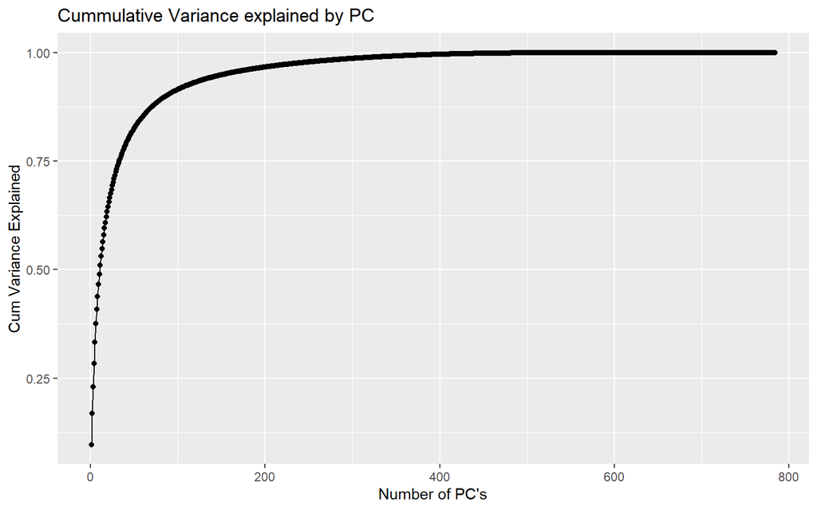

```r
ggplot(var_df,aes(x=1:784, y=cumsum(var_explained))) + geom_line() + geom_point()+
  ggtitle("Cummulative Variance explained by PC") +
  xlab("Number of PC's") + ylab("Cum Variance Explained")
```

**Plot first few PRINCIPAL COMPONENTS**

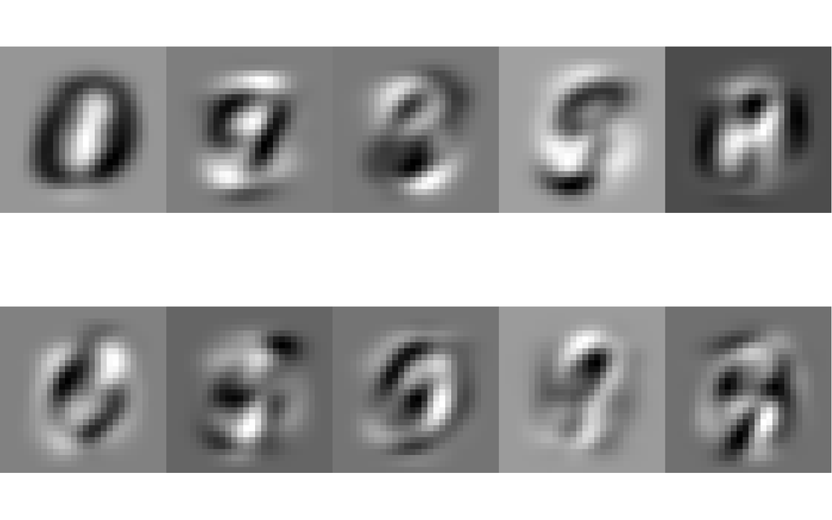

```r
# Plot 10 First COMPONENTS
par(mfrow=c(2,5),mai = c(0.1, 0.1, 0.1, 0.1),mar=c(1, 0, 1, 0))

for (i in 1:10) {
  disp_digit(pca_result$rotation[,i],"")
  }
```

Showing the first n Principal Components looks “noisy”. that is because these are the vectors which explain the most variance of all the dataset with **all numbers** included. So what you are looking at is a mixture of numbers **0 to 9**.

**Print first 10 numbers**

We can also using X number of components **reconstruct** the numbers and PLOT them. Let’s see how they look with only **10 PC’s** out of 784.

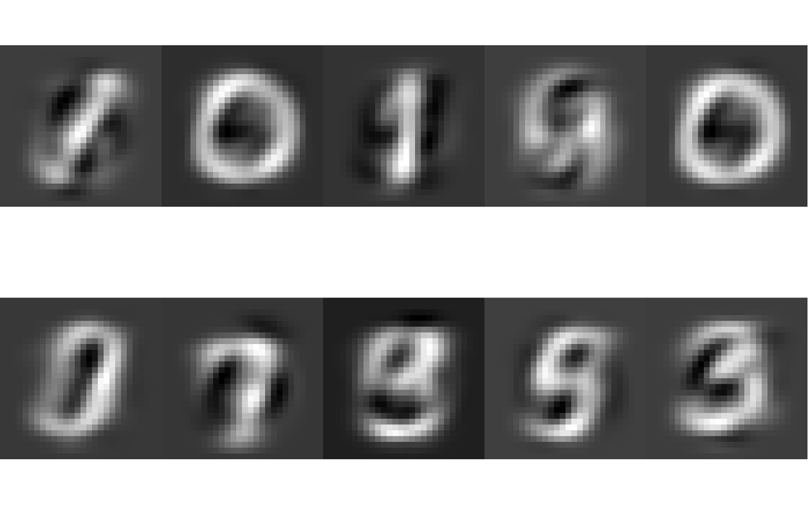

```r
# Plot 10 First Number RECONSTRUCTED with 10 PCS
par(mfrow=c(2,5),mai = c(0.1, 0.1, 0.1, 0.1),mar=c(1, 0, 1, 0))

r <- 10
recon <- t(t(pca_result$x[,1:r] %*% t(pca_result$rotation[,1:r])) + pca_result$center)

for (i in 1:10) {
    disp_digit(recon[i,],"")
  }
```

Not too good. You can’t be sure of the numbers behind. Let’s try with more PC’s, This time **50 PC’s**

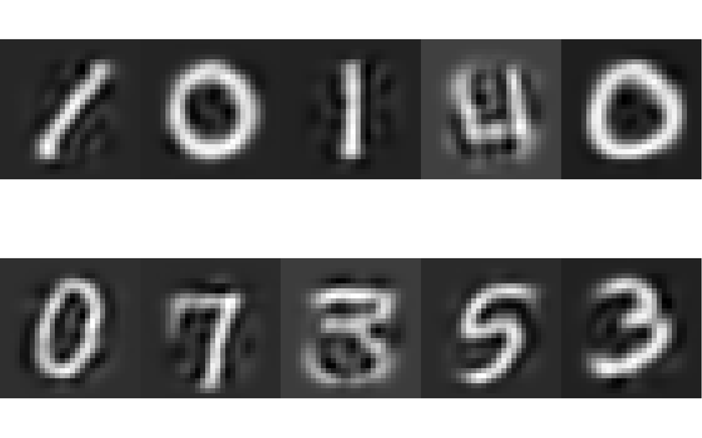

```r
# Plot 10 First Number RECONSTRUCTED with 50 PCS
par(mfrow=c(2,5),mai = c(0.1, 0.1, 0.1, 0.1),mar=c(1, 0, 1, 0))

r <- 50
recon <- t(t(pca_result$x[,1:r] %*% t(pca_result$rotation[,1:r])) + pca_result$center)

for (i in 1:10) {
    disp_digit(recon[i,],"")
  }
```

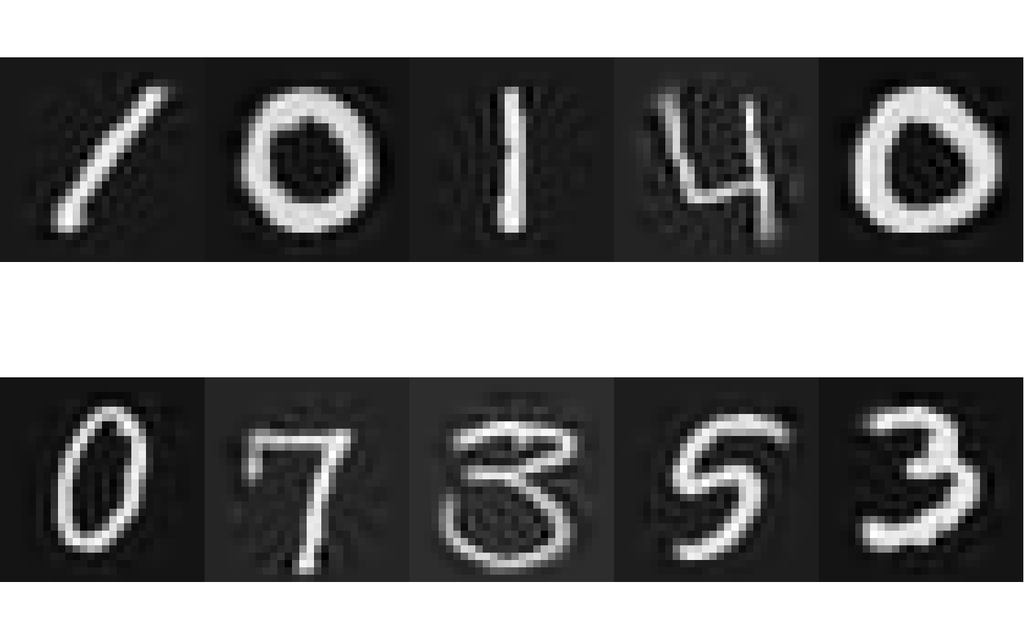

```r
# Plot 10 First Number RECONSTRUCTED with 200 PCS
par(mfrow=c(2,5),mai = c(0.1, 0.1, 0.1, 0.1),mar=c(1, 0, 1, 0))

r <- 200
recon <- t(t(pca_result$x[,1:r] %*% t(pca_result$rotation[,1:r])) + pca_result$center)

for (i in 1:10) {
    disp_digit(recon[i,],"")
  }
```

Much Better. Let this time use as many Principal Components as needed to get 100% of the variance. That is **704 PC’s**

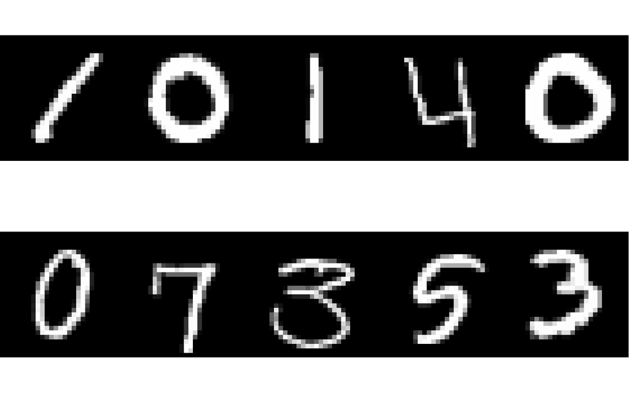

```r
# Plot 10 First Number RECONSTRUCTED 100%
par(mfrow=c(2,5),mai = c(0.1, 0.1, 0.1, 0.1),mar=c(1, 0, 1, 0))

r <- comp_100
recon <- t(t(pca_result$x[,1:r] %*% t(pca_result$rotation[,1:r])) + pca_result$center)

for (i in 1:10) {
    disp_digit(recon[i,],"")
  }
```

Yes. We exactly got the original digits, and we used fewer than the max 784 PC’s.

**Filter only 8’s** Let’s what happens when we re-do the whole PCA analysis but we include only the rows that refer to the **number 8**

```r
train_all8_df <- train_df %>%
  filter(label==8)
```

**Re-run PCA**

```r
# Cal PCA for all 8's in the dataset

pca_result8 <- prcomp(train_all8_df[,2:ncol(train_all8_df)], rank = 784, center=TRUE)
#summary(pca_result8)
```

**Calculate variance only for the 8’s**

```r
# std deviation of each Principal Component
sdev <- pca_result8$sdev
percent_variation <- sdev^2 / sum(sdev^2)

#Variance of PC's
var_df <- data.frame(PC=paste0("PC",1:length(sdev)),
                     var_explained=percent_variation,
                     stringsAsFactors = FALSE)

#Cumulative variance of ordered PC's
cumvar <- cumsum(var_df['var_explained'])
comp_95 <- min(which(cumvar>=0.95))
comp_100 <- min(which(cumvar>=1))

#Variance explained up to 95% and 100%
print(comp_95)
```

```
## [1] 135
```

```r
print(comp_100)
```

```
## [1] 537
```

**Let’s Plot first few PRINCIPAL COMPONENTS**

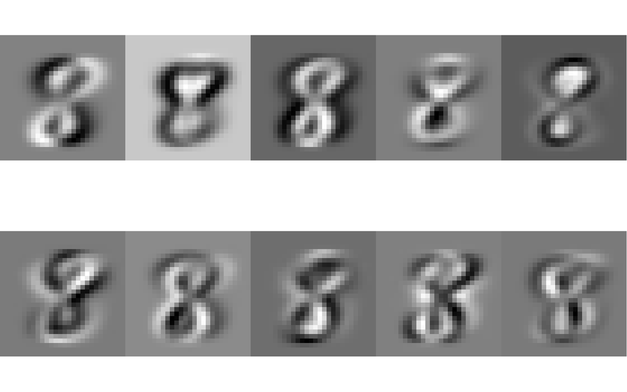

```r
# Plot 10 First COMPONENTS
par(mfrow=c(2,5),mai = c(0.1, 0.1, 0.1, 0.1),mar=c(1, 0, 1, 0))

for (i in 1:10) {
  disp_digit(pca_result8$rotation[,i],"")
  }
```

We can see now the first PC’s capture only the information for the number 8, which now can be distinguished. We can see all refer to the number 8. Please recall we can later reconstruct the original images by combining these “kind of weird looking” images. Let’s do it!

**Display 10 Reconstructed number 8’s**

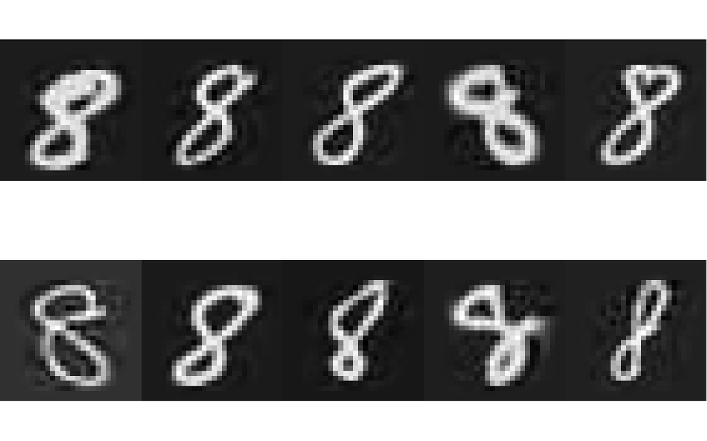

```r
# Plot 10 First Numbers RECONSTRUCTED at 95% variance captured
par(mfrow=c(2,5),mai = c(0.1, 0.1, 0.1, 0.1),mar=c(1, 0, 1, 0))

r <- comp_95
#Let's reconstruct the number
recon <- t(t(pca_result8$x[,1:r] %*% t(pca_result8$rotation[,1:r])) + pca_result8$center)

for (i in 1:10) {
    disp_digit(recon[i,],"")
  }
```

## 2.6 Multinomial Classification Model

Convert labels to factors, as some ML models work only with factors and not characters.

```r
train_df$label <- as.factor(train_df$label)
```

We will use **TIDYMODELS** to setup our basic classification using **multinomial classification**

```r
multinom_spec <-
  multinom_reg(penalty = 0, mixture=1) %>%
  set_mode("classification") %>%
  set_engine("glmnet")
```

**Let’s fit our model!**

```r
doParallel::registerDoParallel()
multinom_fit <- multinom_spec %>%
  fit(label ~ .,
    data = train_df
  )

# multinom_fit
```

Let’s get our results from our fitting.

```r
results_train <- multinom_fit %>%
  predict(new_data = train_df) %>%
  mutate(
    truth = train_df$label
  )
```

```r
results_train %>%
  accuracy(truth, .pred_class)
```

```
## # A tibble: 1 x 3
##   .metric  .estimator .estimate
##   <chr>    <chr>          <dbl>
## 1 accuracy multiclass     0.952
```

We got to an accuracy of **95.2%**

**Lets show the CONFUSION MATRIX**

```r
results_train %>%
  conf_mat(truth, .pred_class)
```

```
##           Truth
## Prediction    0    1    2    3    4    5    6    7    8    9
##          0 4074    0    8    6    4   22   15    4   16    4
##          1    0 4627   16    8   14    7    1   10   41    7
##          2    6    5 3926   75   13   23   18   28   22    6
##          3    5   11   51 4021    3   92    3   10   85   40
##          4    3    0   30    2 3903   32   15   22    9   63
##          5   12    5   15  119    2 3491   35    2   78   22
##          6   13    2   23    4   20   37 4038    2   15    0
##          7    0    4   27   23    9    5    0 4217   11   88
##          8   17   24   69   62   12   69   11   11 3745   26
##          9    2    6   12   31   92   17    1   95   41 3932
```

## 2.7 Keras CLASSIFICATION using a Feedforward Neural Network

Let’s separate our data into train and testing.

```r
mnist_nn_split <- initial_split(train_df)
train <- training(mnist_nn_split)
test <- testing(mnist_nn_split)

y_train <- as.matrix(train$label)
x_train <- as.matrix(train[,-1])
y_test <- as.matrix(test$label)
x_test <- as.matrix(test[,-1])
```

We need to convert some of the features to **categorical**

```r
y_train <- to_categorical(y_train, num_classes = 10)
```

```
## Loaded Tensorflow version 2.3.0
```

```r
y_test <- to_categorical(y_test, num_classes = 10)
```

Let’s define our dense **feed-forward Neural Network**

```r
dense_model <- keras_model_sequential()

dense_model %>%
  layer_dense(units = 128, activation = 'relu', input_shape = c(784)) %>%
  layer_batch_normalization() %>%
  layer_dropout(rate = 0.3) %>%
  layer_dense(units = 32, activation = 'relu') %>%
  layer_batch_normalization() %>%
  layer_dropout(rate = 0.2) %>%
  layer_dense(units = 10, activation = 'softmax')

summary(dense_model)
```

```
## Model: "sequential"
## ________________________________________________________________________________
## Layer (type)                        Output Shape                    Param #
## ================================================================================
## dense_2 (Dense)                     (None, 128)                     100480
## ________________________________________________________________________________
## batch_normalization_1 (BatchNormali (None, 128)                     512
## ________________________________________________________________________________
## dropout_1 (Dropout)                 (None, 128)                     0
## ________________________________________________________________________________
## dense_1 (Dense)                     (None, 32)                      4128
## ________________________________________________________________________________
## batch_normalization (BatchNormaliza (None, 32)                      128
## ________________________________________________________________________________
## dropout (Dropout)                   (None, 32)                      0
## ________________________________________________________________________________
## dense (Dense)                       (None, 10)                      330
## ================================================================================
## Total params: 105,578
## Trainable params: 105,258
## Non-trainable params: 320
## ________________________________________________________________________________
```

We need to compile the model

```r
dense_model %>% compile(
  loss = 'categorical_crossentropy',
  optimizer = optimizer_adam(),
  metrics = c('accuracy')
)
```

Let’s fit our model

```r
history <- dense_model %>% fit(
  x_train, y_train,
  epochs = 20, batch_size = 256,
  validation_split = 0.1
)
```

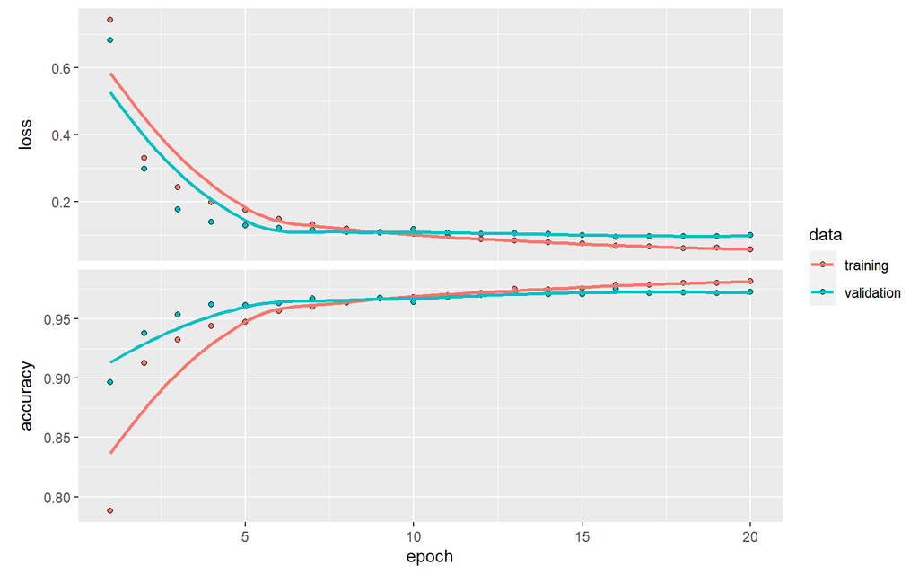

```r
plot(history)
```

```r
dense_model %>% evaluate(x_test, y_test)
```

```
##      loss  accuracy
## 0.1039279 0.9708571
```

**We got to an accuracy of 97%.**

## 2.8 Keras CLASSIFICATION with a Convolutional Neural Network

```r
# Lets reshape the X'
x_trainR <- array_reshape(x_train,c(31500,784,1))
x_testR <- array_reshape(x_test,c(10500,784,1))
```

```r
#  Works now, but you need to re-shape x to add one dime of 1
cnn_model <- keras_model_sequential()

cnn_model %>%
  layer_conv_1d(filters = 32, kernel_size = 3, activation = 'relu',
                input_shape = c(784,1)) %>%
  #layer_max_pooling_1d(pool_size = 3) %>%
  layer_conv_1d(filters = 64, kernel_size = 3, activation = 'relu') %>%
  #layer_global_average_pooling_1d() %>%
  layer_max_pooling_1d(pool_size = 2) %>%
  layer_dropout(rate = 0.2) %>%
  layer_flatten() %>%
  layer_dense(units=128,activation = 'relu') %>%
  layer_dropout(rate = 0.2) %>%
  layer_dense(units = 10, activation = 'softmax') %>%
  compile(
    loss = 'categorical_crossentropy',
    optimizer = optimizer_adam(),
    metrics = c('accuracy')
  )
```

```r
summary(cnn_model)
```

```
## Model: "sequential_1"
## ________________________________________________________________________________
## Layer (type)                        Output Shape                    Param #
## ================================================================================
## conv1d_1 (Conv1D)                   (None, 782, 32)                 128
## ________________________________________________________________________________
## conv1d (Conv1D)                     (None, 780, 64)                 6208
## ________________________________________________________________________________
## max_pooling1d (MaxPooling1D)        (None, 390, 64)                 0
## ________________________________________________________________________________
## dropout_3 (Dropout)                 (None, 390, 64)                 0
## ________________________________________________________________________________
## flatten (Flatten)                   (None, 24960)                   0
## ________________________________________________________________________________
## dense_4 (Dense)                     (None, 128)                     3195008
## ________________________________________________________________________________
## dropout_2 (Dropout)                 (None, 128)                     0
## ________________________________________________________________________________
## dense_3 (Dense)                     (None, 10)                      1290
## ================================================================================
## Total params: 3,202,634
## Trainable params: 3,202,634
## Non-trainable params: 0
## ________________________________________________________________________________
```

```r
cnn_model %>% fit(x_trainR, y_train, batch_size = 128,
                   epochs = 10,validation_split = 0.1)
```

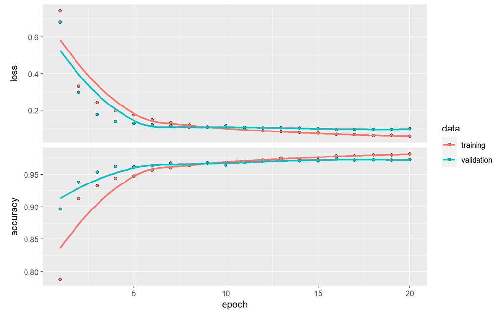

```r
plot(history)
```

```r
cnn_model %>% evaluate(x_testR, y_test, batch_size = 128)
```

```
##      loss  accuracy
## 0.1079240 0.9754286
```

# 3. House Prices Dataset

## 3.1 Load Dataset

```r
#setwd("../HousePrices")
train_df <- read_csv("HousePrices/train.csv")
test_df <- read_csv('HousePrices/test.csv')

head(train_df)
```

```
## # A tibble: 6 x 81
##      Id MSSubClass MSZoning LotFrontage LotArea Street Alley LotShape
##   <dbl>      <dbl> <chr>          <dbl>   <dbl> <chr>  <chr> <chr>
## 1     1         60 RL                65    8450 Pave   <NA>  Reg
## 2     2         20 RL                80    9600 Pave   <NA>  Reg
## 3     3         60 RL                68   11250 Pave   <NA>  IR1
## 4     4         70 RL                60    9550 Pave   <NA>  IR1
## 5     5         60 RL                84   14260 Pave   <NA>  IR1
## 6     6         50 RL                85   14115 Pave   <NA>  IR1
## # ... with 73 more variables: LandContour <chr>, Utilities <chr>,
## #   LotConfig <chr>, LandSlope <chr>, Neighborhood <chr>, Condition1 <chr>,
## #   Condition2 <chr>, BldgType <chr>, HouseStyle <chr>, OverallQual <dbl>,
## #   OverallCond <dbl>, YearBuilt <dbl>, YearRemodAdd <dbl>, RoofStyle <chr>,
## #   RoofMatl <chr>, Exterior1st <chr>, Exterior2nd <chr>, MasVnrType <chr>,
## #   MasVnrArea <dbl>, ExterQual <chr>, ExterCond <chr>, Foundation <chr>,
## #   BsmtQual <chr>, BsmtCond <chr>, BsmtExposure <chr>, BsmtFinType1 <chr>, ...
```

## 3.2 Basic Descriptive Stats

First let’s use **SKIMR**

```r
skimr::skim(train_df)
```

Data summary

| Name | train_df |
| --- | --- |
| Number of rows | 1460 |
| Number of columns | 81 |
| _______________________ |  |
| Column type frequency: |  |
| character | 43 |
| numeric | 38 |
| ________________________ |  |
| Group variables | None |

**Variable type: character**

| skim_variable | n_missing | complete_rate | min | max | empty | n_unique | whitespace |
| --- | --- | --- | --- | --- | --- | --- | --- |
| MSZoning | 0 | 1.00 | 2 | 7 | 0 | 5 | 0 |
| Street | 0 | 1.00 | 4 | 4 | 0 | 2 | 0 |
| Alley | 1369 | 0.06 | 4 | 4 | 0 | 2 | 0 |
| LotShape | 0 | 1.00 | 3 | 3 | 0 | 4 | 0 |
| LandContour | 0 | 1.00 | 3 | 3 | 0 | 4 | 0 |
| Utilities | 0 | 1.00 | 6 | 6 | 0 | 2 | 0 |
| LotConfig | 0 | 1.00 | 3 | 7 | 0 | 5 | 0 |
| LandSlope | 0 | 1.00 | 3 | 3 | 0 | 3 | 0 |
| Neighborhood | 0 | 1.00 | 5 | 7 | 0 | 25 | 0 |
| Condition1 | 0 | 1.00 | 4 | 6 | 0 | 9 | 0 |
| Condition2 | 0 | 1.00 | 4 | 6 | 0 | 8 | 0 |
| BldgType | 0 | 1.00 | 4 | 6 | 0 | 5 | 0 |
| HouseStyle | 0 | 1.00 | 4 | 6 | 0 | 8 | 0 |
| RoofStyle | 0 | 1.00 | 3 | 7 | 0 | 6 | 0 |
| RoofMatl | 0 | 1.00 | 4 | 7 | 0 | 8 | 0 |
| Exterior1st | 0 | 1.00 | 5 | 7 | 0 | 15 | 0 |
| Exterior2nd | 0 | 1.00 | 5 | 7 | 0 | 16 | 0 |
| MasVnrType | 8 | 0.99 | 4 | 7 | 0 | 4 | 0 |
| ExterQual | 0 | 1.00 | 2 | 2 | 0 | 4 | 0 |
| ExterCond | 0 | 1.00 | 2 | 2 | 0 | 5 | 0 |
| Foundation | 0 | 1.00 | 4 | 6 | 0 | 6 | 0 |
| BsmtQual | 37 | 0.97 | 2 | 2 | 0 | 4 | 0 |
| BsmtCond | 37 | 0.97 | 2 | 2 | 0 | 4 | 0 |
| BsmtExposure | 38 | 0.97 | 2 | 2 | 0 | 4 | 0 |
| BsmtFinType1 | 37 | 0.97 | 3 | 3 | 0 | 6 | 0 |
| BsmtFinType2 | 38 | 0.97 | 3 | 3 | 0 | 6 | 0 |
| Heating | 0 | 1.00 | 4 | 5 | 0 | 6 | 0 |
| HeatingQC | 0 | 1.00 | 2 | 2 | 0 | 5 | 0 |
| CentralAir | 0 | 1.00 | 1 | 1 | 0 | 2 | 0 |
| Electrical | 1 | 1.00 | 3 | 5 | 0 | 5 | 0 |
| KitchenQual | 0 | 1.00 | 2 | 2 | 0 | 4 | 0 |
| Functional | 0 | 1.00 | 3 | 4 | 0 | 7 | 0 |
| FireplaceQu | 690 | 0.53 | 2 | 2 | 0 | 5 | 0 |
| GarageType | 81 | 0.94 | 6 | 7 | 0 | 6 | 0 |
| GarageFinish | 81 | 0.94 | 3 | 3 | 0 | 3 | 0 |
| GarageQual | 81 | 0.94 | 2 | 2 | 0 | 5 | 0 |
| GarageCond | 81 | 0.94 | 2 | 2 | 0 | 5 | 0 |
| PavedDrive | 0 | 1.00 | 1 | 1 | 0 | 3 | 0 |
| PoolQC | 1453 | 0.00 | 2 | 2 | 0 | 3 | 0 |
| Fence | 1179 | 0.19 | 4 | 5 | 0 | 4 | 0 |
| MiscFeature | 1406 | 0.04 | 4 | 4 | 0 | 4 | 0 |
| SaleType | 0 | 1.00 | 2 | 5 | 0 | 9 | 0 |
| SaleCondition | 0 | 1.00 | 6 | 7 | 0 | 6 | 0 |

**Variable type: numeric**

| skim_variable | n_missing | complete_rate | mean | sd | p0 | p25 | p50 | p75 | p100 | hist |
| --- | --- | --- | --- | --- | --- | --- | --- | --- | --- | --- |
| Id | 0 | 1.00 | 730.50 | 421.61 | 1 | 365.75 | 730.5 | 1095.25 | 1460 | ▇▇▇▇▇ |
| MSSubClass | 0 | 1.00 | 56.90 | 42.30 | 20 | 20.00 | 50.0 | 70.00 | 190 | ▇▅▂▁▁ |
| LotFrontage | 259 | 0.82 | 70.05 | 24.28 | 21 | 59.00 | 69.0 | 80.00 | 313 | ▇▃▁▁▁ |
| LotArea | 0 | 1.00 | 10516.83 | 9981.26 | 1300 | 7553.50 | 9478.5 | 11601.50 | 215245 | ▇▁▁▁▁ |
| OverallQual | 0 | 1.00 | 6.10 | 1.38 | 1 | 5.00 | 6.0 | 7.00 | 10 | ▁▂▇▅▁ |
| OverallCond | 0 | 1.00 | 5.58 | 1.11 | 1 | 5.00 | 5.0 | 6.00 | 9 | ▁▁▇▅▁ |
| YearBuilt | 0 | 1.00 | 1971.27 | 30.20 | 1872 | 1954.00 | 1973.0 | 2000.00 | 2010 | ▁▂▃▆▇ |
| YearRemodAdd | 0 | 1.00 | 1984.87 | 20.65 | 1950 | 1967.00 | 1994.0 | 2004.00 | 2010 | ▅▂▂▃▇ |
| MasVnrArea | 8 | 0.99 | 103.69 | 181.07 | 0 | 0.00 | 0.0 | 166.00 | 1600 | ▇▁▁▁▁ |
| BsmtFinSF1 | 0 | 1.00 | 443.64 | 456.10 | 0 | 0.00 | 383.5 | 712.25 | 5644 | ▇▁▁▁▁ |
| BsmtFinSF2 | 0 | 1.00 | 46.55 | 161.32 | 0 | 0.00 | 0.0 | 0.00 | 1474 | ▇▁▁▁▁ |
| BsmtUnfSF | 0 | 1.00 | 567.24 | 441.87 | 0 | 223.00 | 477.5 | 808.00 | 2336 | ▇▅▂▁▁ |
| TotalBsmtSF | 0 | 1.00 | 1057.43 | 438.71 | 0 | 795.75 | 991.5 | 1298.25 | 6110 | ▇▃▁▁▁ |
| 1stFlrSF | 0 | 1.00 | 1162.63 | 386.59 | 334 | 882.00 | 1087.0 | 1391.25 | 4692 | ▇▅▁▁▁ |
| 2ndFlrSF | 0 | 1.00 | 346.99 | 436.53 | 0 | 0.00 | 0.0 | 728.00 | 2065 | ▇▃▂▁▁ |
| LowQualFinSF | 0 | 1.00 | 5.84 | 48.62 | 0 | 0.00 | 0.0 | 0.00 | 572 | ▇▁▁▁▁ |
| GrLivArea | 0 | 1.00 | 1515.46 | 525.48 | 334 | 1129.50 | 1464.0 | 1776.75 | 5642 | ▇▇▁▁▁ |
| BsmtFullBath | 0 | 1.00 | 0.43 | 0.52 | 0 | 0.00 | 0.0 | 1.00 | 3 | ▇▆▁▁▁ |
| BsmtHalfBath | 0 | 1.00 | 0.06 | 0.24 | 0 | 0.00 | 0.0 | 0.00 | 2 | ▇▁▁▁▁ |
| FullBath | 0 | 1.00 | 1.57 | 0.55 | 0 | 1.00 | 2.0 | 2.00 | 3 | ▁▇▁▇▁ |
| HalfBath | 0 | 1.00 | 0.38 | 0.50 | 0 | 0.00 | 0.0 | 1.00 | 2 | ▇▁▅▁▁ |
| BedroomAbvGr | 0 | 1.00 | 2.87 | 0.82 | 0 | 2.00 | 3.0 | 3.00 | 8 | ▁▇▂▁▁ |
| KitchenAbvGr | 0 | 1.00 | 1.05 | 0.22 | 0 | 1.00 | 1.0 | 1.00 | 3 | ▁▇▁▁▁ |
| TotRmsAbvGrd | 0 | 1.00 | 6.52 | 1.63 | 2 | 5.00 | 6.0 | 7.00 | 14 | ▂▇▇▁▁ |
| Fireplaces | 0 | 1.00 | 0.61 | 0.64 | 0 | 0.00 | 1.0 | 1.00 | 3 | ▇▇▁▁▁ |
| GarageYrBlt | 81 | 0.94 | 1978.51 | 24.69 | 1900 | 1961.00 | 1980.0 | 2002.00 | 2010 | ▁▁▅▅▇ |
| GarageCars | 0 | 1.00 | 1.77 | 0.75 | 0 | 1.00 | 2.0 | 2.00 | 4 | ▁▃▇▂▁ |
| GarageArea | 0 | 1.00 | 472.98 | 213.80 | 0 | 334.50 | 480.0 | 576.00 | 1418 | ▂▇▃▁▁ |
| WoodDeckSF | 0 | 1.00 | 94.24 | 125.34 | 0 | 0.00 | 0.0 | 168.00 | 857 | ▇▂▁▁▁ |
| OpenPorchSF | 0 | 1.00 | 46.66 | 66.26 | 0 | 0.00 | 25.0 | 68.00 | 547 | ▇▁▁▁▁ |
| EnclosedPorch | 0 | 1.00 | 21.95 | 61.12 | 0 | 0.00 | 0.0 | 0.00 | 552 | ▇▁▁▁▁ |
| 3SsnPorch | 0 | 1.00 | 3.41 | 29.32 | 0 | 0.00 | 0.0 | 0.00 | 508 | ▇▁▁▁▁ |
| ScreenPorch | 0 | 1.00 | 15.06 | 55.76 | 0 | 0.00 | 0.0 | 0.00 | 480 | ▇▁▁▁▁ |
| PoolArea | 0 | 1.00 | 2.76 | 40.18 | 0 | 0.00 | 0.0 | 0.00 | 738 | ▇▁▁▁▁ |
| MiscVal | 0 | 1.00 | 43.49 | 496.12 | 0 | 0.00 | 0.0 | 0.00 | 15500 | ▇▁▁▁▁ |
| MoSold | 0 | 1.00 | 6.32 | 2.70 | 1 | 5.00 | 6.0 | 8.00 | 12 | ▃▆▇▃▃ |
| YrSold | 0 | 1.00 | 2007.82 | 1.33 | 2006 | 2007.00 | 2008.0 | 2009.00 | 2010 | ▇▇▇▇▅ |
| SalePrice | 0 | 1.00 | 180921.20 | 79442.50 | 34900 | 129975.00 | 163000.0 | 214000.00 | 755000 | ▇▅▁▁▁ |

Let’s take a look at basic stats

```r
summary(train_df)
```

```
##        Id           MSSubClass      MSZoning          LotFrontage
##  Min.   :   1.0   Min.   : 20.0   Length:1460        Min.   : 21.00
##  1st Qu.: 365.8   1st Qu.: 20.0   Class :character   1st Qu.: 59.00
##  Median : 730.5   Median : 50.0   Mode  :character   Median : 69.00
##  Mean   : 730.5   Mean   : 56.9                      Mean   : 70.05
##  3rd Qu.:1095.2   3rd Qu.: 70.0                      3rd Qu.: 80.00
##  Max.   :1460.0   Max.   :190.0                      Max.   :313.00
##                                                      NA's   :259
##     LotArea          Street             Alley             LotShape
##  Min.   :  1300   Length:1460        Length:1460        Length:1460
##  1st Qu.:  7554   Class :character   Class :character   Class :character
##  Median :  9478   Mode  :character   Mode  :character   Mode  :character
##  Mean   : 10517
##  3rd Qu.: 11602
##  Max.   :215245
##
##  LandContour         Utilities          LotConfig          LandSlope
##  Length:1460        Length:1460        Length:1460        Length:1460
##  Class :character   Class :character   Class :character   Class :character
##  Mode  :character   Mode  :character   Mode  :character   Mode  :character
##
##
##
##
##  Neighborhood        Condition1         Condition2          BldgType
##  Length:1460        Length:1460        Length:1460        Length:1460
##  Class :character   Class :character   Class :character   Class :character
##  Mode  :character   Mode  :character   Mode  :character   Mode  :character
##
##
##
##
##   HouseStyle         OverallQual      OverallCond      YearBuilt
##  Length:1460        Min.   : 1.000   Min.   :1.000   Min.   :1872
##  Class :character   1st Qu.: 5.000   1st Qu.:5.000   1st Qu.:1954
##  Mode  :character   Median : 6.000   Median :5.000   Median :1973
##                     Mean   : 6.099   Mean   :5.575   Mean   :1971
##                     3rd Qu.: 7.000   3rd Qu.:6.000   3rd Qu.:2000
##                     Max.   :10.000   Max.   :9.000   Max.   :2010
##
```

[output cut: 113 more lines]

```
##  Min.   : 1.000   Min.   :2006   Length:1460        Length:1460
##  1st Qu.: 5.000   1st Qu.:2007   Class :character   Class :character
##  Median : 6.000   Median :2008   Mode  :character   Mode  :character
##  Mean   : 6.322   Mean   :2008
##  3rd Qu.: 8.000   3rd Qu.:2009
##  Max.   :12.000   Max.   :2010
##
##    SalePrice
##  Min.   : 34900
##  1st Qu.:129975
##  Median :163000
##  Mean   :180921
##  3rd Qu.:214000
##  Max.   :755000
##
```

## 3.3 Correlation Plots

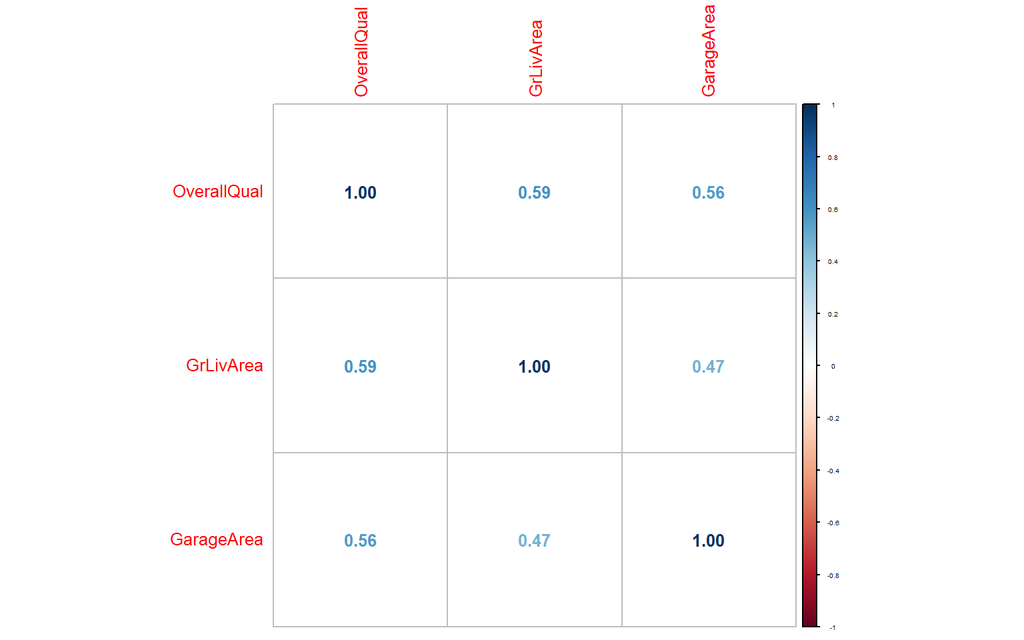

```r
par(mfrow=c(1,1))
library(corrplot)
corr_df <- select_if(train_df, is.numeric)

#Select 3 variables
corr_3var_df <- corr_df %>%
  dplyr::select(OverallQual,GrLivArea,GarageArea)

cormat <- round(cor(corr_3var_df,use = "complete.obs"),2)
corrplot(cormat, method="number",
         tl.cex = 0.8,
         number.cex = 0.8,
         cl.cex = 0.3)
```

Another flavor of Correlation Plots

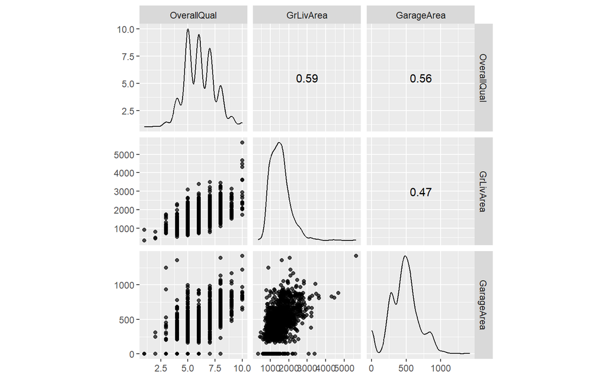

```r
#
library(GGally)
corr_3var_df %>%
  ggscatmat(alpha = 0.7)
```

## 3.4 Scatter Plots (Selected variables)

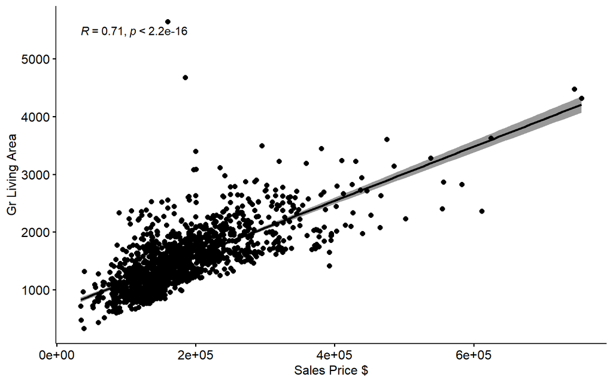

```r
library("ggpubr")
ggscatter(corr_df, x = "SalePrice", y = "GrLivArea",
          add = "reg.line", conf.int = TRUE,
          cor.coef = TRUE, cor.method = "pearson",
          xlab = "Sales Price $", ylab = "Gr Living Area")
```

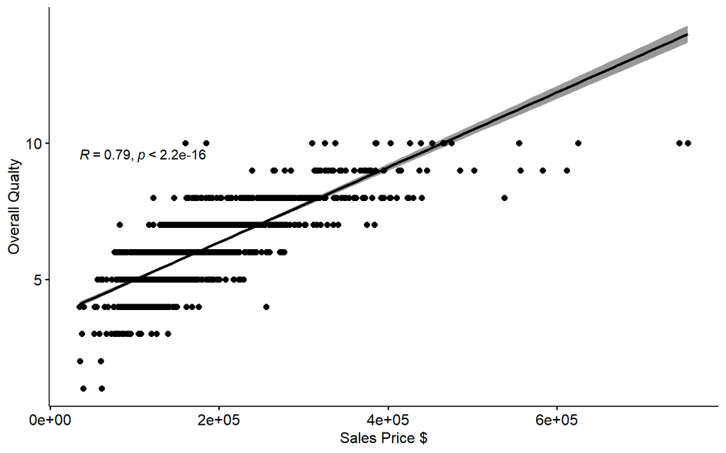

```r
ggscatter(corr_df, x = "SalePrice", y = "OverallQual",
          add = "reg.line", conf.int = TRUE,
          cor.coef = TRUE, cor.method = "pearson",
          xlab = "Sales Price $", ylab = "Overall Qualty")
```

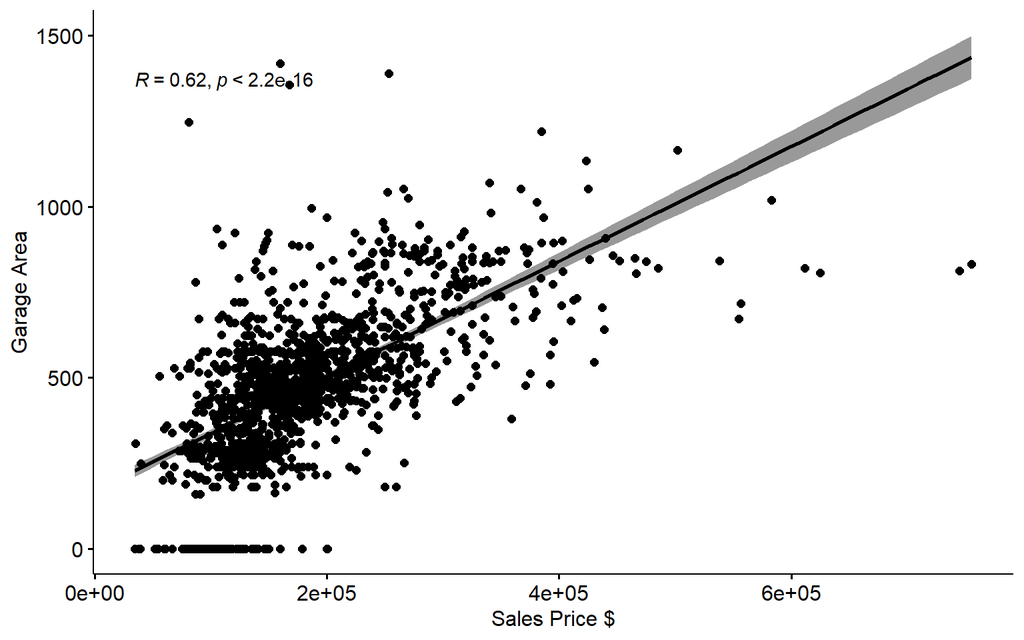

```r
ggscatter(corr_df, x = "SalePrice", y = "GarageArea",
          add = "reg.line", conf.int = TRUE,
          cor.coef = TRUE, cor.method = "pearson",
          xlab = "Sales Price $", ylab = "Garage Area")
```

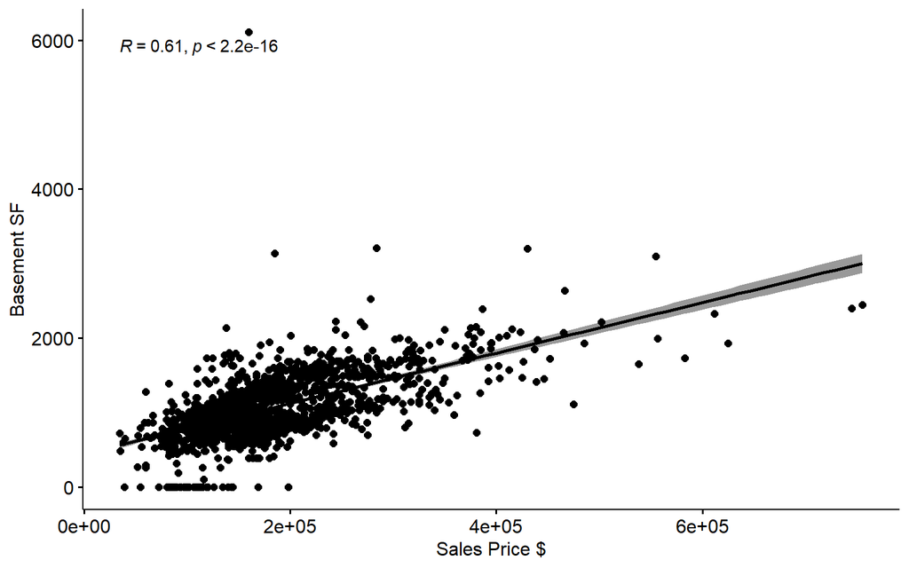

```r
ggscatter(corr_df, x = "SalePrice", y = "TotalBsmtSF",
          add = "reg.line", conf.int = TRUE,
          cor.coef = TRUE, cor.method = "pearson",
          xlab = "Sales Price $", ylab = "Basement SF")
```

## 3.5 Calculate Shapiro Test for normality.

```r
for (i in colnames(corr_df)){       # for-loop over columns
  res <- shapiro.test(corr_df[[i]])$p
  print(paste0(i," ",res))
}
```

```
## [1] "Id 7.97201340256573e-21"
## [1] "MSSubClass 9.10819385467262e-39"
## [1] "LotFrontage 2.00169250796826e-29"
## [1] "LotArea 7.93365433408252e-58"
## [1] "OverallQual 2.68645715997021e-22"
## [1] "OverallCond 6.77422906906633e-37"
## [1] "YearBuilt 2.7702198520757e-26"
## [1] "YearRemodAdd 6.72028021924094e-34"
## [1] "MasVnrArea 6.5566451859357e-48"
## [1] "BsmtFinSF1 2.81385360889394e-35"
## [1] "BsmtFinSF2 1.85025360137009e-58"
## [1] "BsmtUnfSF 1.63991082180453e-25"
## [1] "TotalBsmtSF 1.61133243783591e-27"
## [1] "1stFlrSF 4.51322308307649e-26"
## [1] "2ndFlrSF 2.51488232422664e-41"
```

[output cut: 23 more lines]

**Pearson correlation to SalePrice** We will run Pearson correlation of all numerical features against the objective variable **SalePrice**.

```r
# Create list of Pearson Correlation coefficient
mylist <- list()

for (i in colnames(corr_df)){       # for-loop over columns
  res <- cor(corr_df[[i]],corr_df$SalePrice,method = "pearson", use = "complete.obs")
  mylist[[ i ]] <- res
}
#mylist
```

```r
#Sort by value decreasing order
sorted_mylist <- mylist[order(unlist(mylist), decreasing=TRUE)]
sorted_mylist
```

```
## $SalePrice
## [1] 1
##
## $OverallQual
## [1] 0.7909816
##
## $GrLivArea
## [1] 0.7086245
##
## $GarageCars
## [1] 0.6404092
##
## $GarageArea
## [1] 0.6234314
##
## $TotalBsmtSF
## [1] 0.6135806
##
## $`1stFlrSF`
## [1] 0.6058522
##
## $FullBath
## [1] 0.5606638
##
## $TotRmsAbvGrd
## [1] 0.5337232
##
## $YearBuilt
## [1] 0.5228973
##
## $YearRemodAdd
## [1] 0.507101
##
## $GarageYrBlt
## [1] 0.4863617
##
## $MasVnrArea
## [1] 0.477493
##
## $Fireplaces
```

[output cut: 58 more lines]

```
##
## $YrSold
## [1] -0.02892259
##
## $OverallCond
## [1] -0.07785589
##
## $MSSubClass
## [1] -0.08428414
##
## $EnclosedPorch
## [1] -0.128578
##
## $KitchenAbvGr
## [1] -0.1359074
```

**Top 5 correlated variables where:**

1. OverallQual
2. GrLivArea
3. GarageCars
4. GarageArea
5. TotalBsmtSF

## 3.6 Test Pairwise Correlation Hypothesis at 80% CI

```r
cor.test(corr_df$OverallQual, corr_df$GrLivArea, method = "pearson", conf.level = 0.80)
```

```
##
##  Pearson's product-moment correlation
##
## data:  corr_df$OverallQual and corr_df$GrLivArea
## t = 28.121, df = 1458, p-value < 2.2e-16
## alternative hypothesis: true correlation is not equal to 0
## 80 percent confidence interval:
##  0.5708061 0.6143422
## sample estimates:
##       cor
## 0.5930074
```

```r
cor.test(corr_df$OverallQual, corr_df$GarageArea, method = "pearson", conf.level = 0.80)
```

```
##
##  Pearson's product-moment correlation
##
## data:  corr_df$OverallQual and corr_df$GarageArea
## t = 25.946, df = 1458, p-value < 2.2e-16
## alternative hypothesis: true correlation is not equal to 0
## 80 percent confidence interval:
##  0.5386198 0.5845573
## sample estimates:
##       cor
## 0.5620218
```

```r
cor.test(corr_df$GarageArea, corr_df$GrLivArea, method = "pearson", conf.level = 0.80)
```

```
##
##  Pearson's product-moment correlation
##
## data:  corr_df$GarageArea and corr_df$GrLivArea
## t = 20.276, df = 1458, p-value < 2.2e-16
## alternative hypothesis: true correlation is not equal to 0
## 80 percent confidence interval:
##  0.4423993 0.4947713
## sample estimates:
##       cor
## 0.4689975
```

The P-values are very small. Probability of error that there is **no correlation** between variables is very small.

## 3.7 Precision Matrix and LU Decomposition

```r
precision_mat <- solve(cormat)
```

```r
precision_mat %*% cormat
```

```
##               OverallQual    GrLivArea   GarageArea
## OverallQual  1.000000e+00 5.551115e-17 0.000000e+00
## GrLivArea    5.551115e-17 1.000000e+00 1.110223e-16
## GarageArea  -1.110223e-16 0.000000e+00 1.000000e+00
```

```r
cormat %*% precision_mat
```

```
##               OverallQual    GrLivArea   GarageArea
## OverallQual  1.000000e+00 2.775558e-17 0.000000e+00
## GrLivArea    0.000000e+00 1.000000e+00 1.110223e-16
## GarageArea  -1.110223e-16 5.551115e-17 1.000000e+00
```

```r
lu.decomp <- function(M){
  rows <- dim(M)[1]
  cols <- dim(M)[2]

  if (rows != cols) {
    return(list(0,0))} #If is not square matrix return list of 0's
  else {
    L <- diag(x = 1, rows,cols) # L by definition has 1's in the diagonal
    U <- M # Upper will have its first row EQUAL to input matrix
    for (x in 1:(rows-1)){
      for (y in (x+1):rows){
          factor = U[y,x]/U[x,x] # Is the number used to eliminate
          L[y,x] = factor # We make the lower matrix that value
          U[y,] = U[y,]-factor*U[x,] # We use Gaussian elimination
      }
    }
    return(list("L"=L,"U"=U)) # We return our completed L and U matrices
  }
}
```

```r
lu <- lu.decomp(cormat)
lu
```

```
## $L
##      [,1]      [,2] [,3]
## [1,] 1.00 0.0000000    0
## [2,] 0.59 1.0000000    0
## [3,] 0.56 0.2141433    1
##
## $U
##             OverallQual GrLivArea GarageArea
## OverallQual           1    0.5900  0.5600000
## GrLivArea             0    0.6519  0.1396000
## GarageArea            0    0.0000  0.6565056
```

Lets’ check manual results vs function in **matrixcalc** library

```r
library(matrixcalc)
lu.decomposition(cormat)
```

```
## $L
##      [,1]      [,2] [,3]
## [1,] 1.00 0.0000000    0
## [2,] 0.59 1.0000000    0
## [3,] 0.56 0.2141433    1
##
## $U
##      [,1]   [,2]      [,3]
## [1,]    1 0.5900 0.5600000
## [2,]    0 0.6519 0.1396000
## [3,]    0 0.0000 0.6565056
```

**Same result both ways, which is comforting**

## 3.8 Analysis Selected Skewed Variable

Plot Histogram of variable **OpenPorchSF**

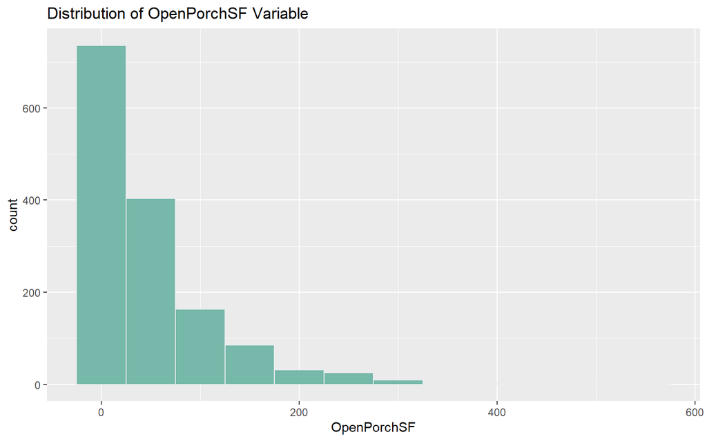

```r
# plot
p <- train_df %>%
  # filter( price<300 ) %>%
  ggplot( aes(x=OpenPorchSF)) +
    geom_histogram( binwidth=50, fill="#69b3a2", color="#e9ecef", alpha=0.9) +
    ggtitle("Distribution of OpenPorchSF Variable")

p
```

Use **fitdistr** in **MASS** library

```r
library(MASS)
```

Find the **lambda** parameter and use it to simulate an exponential distribution

```r
resfit <- fitdistr(train_df$OpenPorchSF, "exponential")
```

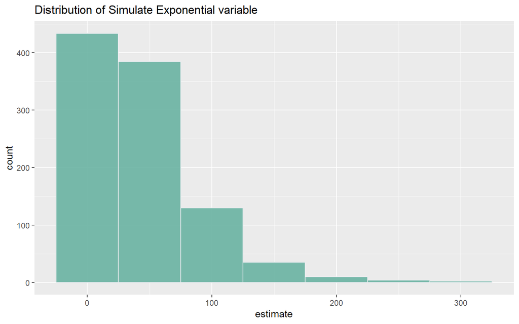

```r
simulated <- as.data.frame(rexp(1000,resfit$estimate))
colnames(simulated) <- c("estimate")

simulated %>%
  ggplot( aes(x=estimate)) +
    geom_histogram( binwidth=50, fill="#69b3a2", color="#e9ecef", alpha=0.9) +
    ggtitle("Distribution of Simulate Exponential variable")
```

**We can simulate results and see they are also skewed, but not quite the same distribution as the empirical data.**

## 3.9 Find 5th and 95th percentile of cumulative distribution

```r
qexp(.05, rate=resfit$estimate)
```

```
## [1] 2.393359
```

```r
qexp(.95, rate=resfit$estimate)
```

```
## [1] 139.7817
```

Generate a 95% confidence interval from the empirical data, assuming normality.

```r
# Calculate the mean and standard error
l.model <- lm(OpenPorchSF ~ 1, train_df)

# Calculate the confidence interval
confint(l.model, level=0.95)
```

```
##                2.5 %   97.5 %
## (Intercept) 43.25888 50.06167
```

**Let’s try also manually to see the results and compare them.**

```r
#Manual way of calculating CI
sample.mean <- mean(train_df$OpenPorchSF)
print(sample.mean)
```

```
## [1] 46.66027
```

```r
sample.n <- length(train_df$OpenPorchSF)
sample.sd <- sd(train_df$OpenPorchSF)
sample.se <- sample.sd/sqrt(sample.n)
print(sample.se)
```

```
## [1] 1.733999
```

```r
alpha = 0.05
degrees.freedom = sample.n - 1
t.score = qt(p=alpha/2, df=degrees.freedom,lower.tail=F)
print(t.score)
```

```
## [1] 1.961591
```

```r
margin.error <- t.score * sample.se
lower.bound <- sample.mean - margin.error
upper.bound <- sample.mean + margin.error
print(c(lower.bound,upper.bound))
```

```
## [1] 43.25888 50.06167
```

```r
#Provide the empirical 5th percentile and 95th percentile of the data.

quantile(x=train_df$OpenPorchSF, probs=c(.05, .95))
```

```
##     5%    95%
##   0.00 175.05
```

## 3.10 Modelling (Machine Learning)

We will use **TIDYMODELS** to prepare and fit a collection of model using a **grid search** method of testing many hyper-parameters. We will fit Lasso regression with regularization and also **XGBoost** for regression. We will check results from **cross-validation** and select the model and hyper-parameters which performs the best on validation data.

### 3.10.1 Prepare data

```r
#convert all char to factors
train_df <- mutate(train_df, across(where(is.character), as.factor))
test_df <- mutate(test_df, across(where(is.character), as.factor))
#test_df2 <- mutate(test_df2, across(where(is.character), as.factor))
```

### 3.10.2 Split data training and test

```r
set.seed(42)
sales_split <- initial_split(train_df, prop=9/10)
sales_train <- training(sales_split)
sales_test <- testing(sales_split)
```

### 3.10.3 Pre-process with RECIPES

```r
# will test with 3 different options to data engineering

sales_recipe1 <- recipe(SalePrice ~ ., data = sales_train) %>%
  step_impute_knn(all_predictors(), neighbors = 50) %>%
  step_dummy(all_nominal(), -all_outcomes()) %>%
  step_zv(all_numeric_predictors()) %>%
  step_normalize(all_numeric_predictors()) %>%
  prep()

sales_prep1 <- prep(sales_recipe1)
#sales_prep1

sales_recipe2 <- recipe(SalePrice ~ ., data = sales_train) %>%
  step_impute_mode(all_nominal()) %>%
  step_impute_mean(all_numeric_predictors()) %>%
  step_dummy(all_nominal(), -all_outcomes()) %>%
  step_zv(all_numeric_predictors()) %>%
  step_normalize(all_numeric_predictors()) %>%
  prep()

sales_prep2 <- prep(sales_recipe2)

sales_recipe3 <- recipe(SalePrice ~ ., data = sales_train) %>%
  step_impute_mode(all_nominal()) %>%
  step_impute_mean(all_numeric_predictors()) %>%
  step_BoxCox(all_numeric_predictors()) %>%
  step_dummy(all_nominal(), -all_outcomes()) %>%
  step_zv(all_numeric_predictors()) %>%
  step_normalize(all_numeric_predictors()) %>%
  prep()

sales_prep3 <- prep(sales_recipe3)
```

### 3.10.4 Define Cross-Validation Folds

```r
## Cross Validation Split of Training Data
set.seed(42)
sales_folds <- vfold_cv(
  data = sales_train,
  v = 10
  )

#sales_folds
```

### 3.10.5 Define Models

```r
# Linear Regression
lm_spec <- linear_reg() %>%
            set_engine('lm') %>%
            set_mode('regression')

#lm_spec
```

```r
# Lasso Regression
lasso_spec <- linear_reg(mode = "regression",
                        penalty = tune(),
                        mixture = 1) %>%
  set_engine("glmnet")

#lasso_spec
```

```r
# XGBoost Regression
xgboost_spec <- boost_tree(
  trees = tune(),
  mtry = tune(),
  tree_depth = tune(),
  learn_rate = tune()
  ) %>%
  set_mode("regression") %>%
  set_engine("xgboost")
```

### 3.10.6 Define workflow set

Let’s stack the models we want to compare.

```r
workflow_set <-workflow_set(
  preproc = list(sales_recipe1,sales_recipe2, sales_recipe3),
  models = list(lasso_spec, xgboost_spec),
  cross = TRUE
  )

workflow_set
```

```
## # A workflow set/tibble: 6 x 4
##   wflow_id            info             option    result
##   <chr>               <list>           <list>    <list>
## 1 recipe_1_linear_reg <tibble [1 x 4]> <opts[0]> <list [0]>
## 2 recipe_1_boost_tree <tibble [1 x 4]> <opts[0]> <list [0]>
## 3 recipe_2_linear_reg <tibble [1 x 4]> <opts[0]> <list [0]>
## 4 recipe_2_boost_tree <tibble [1 x 4]> <opts[0]> <list [0]>
## 5 recipe_3_linear_reg <tibble [1 x 4]> <opts[0]> <list [0]>
## 6 recipe_3_boost_tree <tibble [1 x 4]> <opts[0]> <list [0]>
```

### 3.10.7 Fit the stack of Models and Recipes

Here we fit the models and use hyper-parameter tuning using 150 levels.

```r
# The fitting lasted 5.5 hours in my PC.  I save the model results in order to easily knit. For actually running the fit, please change RUN = TRUE

RUN = FALSE
if (RUN) {
doParallel::registerDoParallel()
start.time <- Sys.time()
start.time
fit_workflows <- workflow_set %>%
  workflow_map(
    seed = 42,
    fn = "tune_grid",
    grid = 150,
    resamples = sales_folds,
    verbose = TRUE
  )

end.time <- Sys.time()
time.taken <- end.time - start.time
time.taken
doParallel::stopImplicitCluster()
}
```

**The fitting took 5.5 hours on a i7 Gen 11 machine with 32G of RAM.**

### 3.10.8 Save/Load resulting model (backup)

```r
if (RUN) {
saved_housesales_modelset <- fit_workflows
saveRDS(saved_housesales_modelset, "HousePrices/housesales.rds")
}
########
if (!RUN) {
fit_workflows <- readRDS("HousePrices/housesales.rds")
}
```

### 3.10.9 Review Results of all models

Let’s see how our models performed and choose a winner.

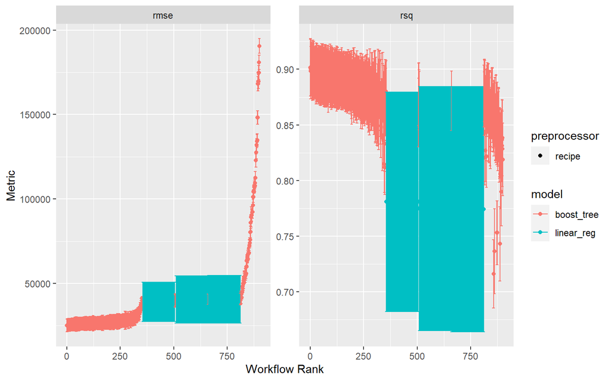

```r
autoplot(fit_workflows)
```

```r
collect_metrics(fit_workflows)
```

```
## # A tibble: 1,800 x 9
##    wflow_id       .config preproc model .metric .estimator    mean     n std_err
##    <chr>          <chr>   <chr>   <chr> <chr>   <chr>        <dbl> <int>   <dbl>
##  1 recipe_1_line~ Prepro~ recipe  line~ rmse    standard   4.05e+4    10 8.50e+3
##  2 recipe_1_line~ Prepro~ recipe  line~ rsq     standard   7.75e-1    10 6.66e-2
##  3 recipe_1_line~ Prepro~ recipe  line~ rmse    standard   4.05e+4    10 8.50e+3
##  4 recipe_1_line~ Prepro~ recipe  line~ rsq     standard   7.75e-1    10 6.66e-2
##  5 recipe_1_line~ Prepro~ recipe  line~ rmse    standard   4.05e+4    10 8.50e+3
##  6 recipe_1_line~ Prepro~ recipe  line~ rsq     standard   7.75e-1    10 6.66e-2
##  7 recipe_1_line~ Prepro~ recipe  line~ rmse    standard   4.05e+4    10 8.50e+3
##  8 recipe_1_line~ Prepro~ recipe  line~ rsq     standard   7.75e-1    10 6.66e-2
##  9 recipe_1_line~ Prepro~ recipe  line~ rmse    standard   4.05e+4    10 8.50e+3
## 10 recipe_1_line~ Prepro~ recipe  line~ rsq     standard   7.75e-1    10 6.66e-2
## # ... with 1,790 more rows
```

```r
rank_results(fit_workflows, rank_metric = "rmse", select_best = TRUE)
```

```
## # A tibble: 12 x 9
##    wflow_id       .config .metric    mean std_err     n preprocessor model  rank
##    <chr>          <chr>   <chr>     <dbl>   <dbl> <int> <chr>        <chr> <int>
##  1 recipe_3_boos~ Prepro~ rmse    2.51e+4 2.33e+3    10 recipe       boos~     1
##  2 recipe_3_boos~ Prepro~ rsq     9.02e-1 1.55e-2    10 recipe       boos~     1
##  3 recipe_2_boos~ Prepro~ rmse    2.52e+4 2.42e+3    10 recipe       boos~     2
##  4 recipe_2_boos~ Prepro~ rsq     9.01e-1 1.64e-2    10 recipe       boos~     2
##  5 recipe_1_boos~ Prepro~ rmse    2.53e+4 2.24e+3    10 recipe       boos~     3
##  6 recipe_1_boos~ Prepro~ rsq     8.98e-1 1.34e-2    10 recipe       boos~     3
##  7 recipe_3_line~ Prepro~ rmse    3.91e+4 7.10e+3    10 recipe       line~     4
##  8 recipe_3_line~ Prepro~ rsq     7.81e-1 6.00e-2    10 recipe       line~     4
##  9 recipe_1_line~ Prepro~ rmse    4.05e+4 8.50e+3    10 recipe       line~     5
## 10 recipe_1_line~ Prepro~ rsq     7.75e-1 6.66e-2    10 recipe       line~     5
## 11 recipe_2_line~ Prepro~ rmse    4.06e+4 8.57e+3    10 recipe       line~     6
## 12 recipe_2_line~ Prepro~ rsq     7.74e-1 6.71e-2    10 recipe       line~     6
```

**Extract the best workflow**

```r
metric <- "rmse"

best_workflow_id <- fit_workflows %>%
  rank_results(
    rank_metric = metric,
    select_best = TRUE
  ) %>%
  dplyr::slice(1) %>%
  pull(wflow_id)

workflow_best <- extract_workflow(fit_workflows, id = best_workflow_id)

best_workflow_id
```

```
## [1] "recipe_3_boost_tree"
```

**Extract tuning results from workflowset**

We know our best model in training, now let’s extract the tuning parameters used to generate it.

```r
workflow_best_tuned <- fit_workflows[fit_workflows$wflow_id == best_workflow_id,"result"][[1]][[1]]

workflow_best_tuned
```

```
## # Tuning results
## # 10-fold cross-validation
## # A tibble: 10 x 4
##    splits             id     .metrics           .notes
##    <list>             <chr>  <list>             <list>
##  1 <split [1182/132]> Fold01 <tibble [300 x 8]> <tibble [1 x 3]>
##  2 <split [1182/132]> Fold02 <tibble [300 x 8]> <tibble [1 x 3]>
##  3 <split [1182/132]> Fold03 <tibble [300 x 8]> <tibble [1 x 3]>
##  4 <split [1182/132]> Fold04 <tibble [300 x 8]> <tibble [1 x 3]>
##  5 <split [1183/131]> Fold05 <tibble [300 x 8]> <tibble [1 x 3]>
##  6 <split [1183/131]> Fold06 <tibble [300 x 8]> <tibble [1 x 3]>
##  7 <split [1183/131]> Fold07 <tibble [300 x 8]> <tibble [1 x 3]>
##  8 <split [1183/131]> Fold08 <tibble [300 x 8]> <tibble [1 x 3]>
##  9 <split [1183/131]> Fold09 <tibble [300 x 8]> <tibble [1 x 3]>
## 10 <split [1183/131]> Fold10 <tibble [300 x 8]> <tibble [1 x 3]>
##
## There were issues with some computations:
##
##   - Warning(s) x10: Non-positive values in selected variable., Fewer than `num_unique...
##
## Run `show_notes(.Last.tune.result)` for more information.
```

```r
collect_metrics(workflow_best_tuned)
```

```
## # A tibble: 300 x 10
##     mtry trees tree_depth learn_rate .metric .estimator      mean     n  std_err
##    <int> <int>      <int>      <dbl> <chr>   <chr>          <dbl> <int>    <dbl>
##  1     2   677          2    0.00175 rmse    standard   89327.       10  3.60e+3
##  2     2   677          2    0.00175 rsq     standard       0.736    10  2.32e-2
##  3     3   102          7    0.0562  rmse    standard   30858.       10  2.43e+3
##  4     3   102          7    0.0562  rsq     standard       0.859    10  1.60e-2
##  5     6  1851          9    0.0244  rmse    standard   25683.       10  2.30e+3
##  6     6  1851          9    0.0244  rsq     standard       0.897    10  1.60e-2
##  7     6   283         11    0.00579 rmse    standard   54772.       10  2.56e+3
##  8     6   283         11    0.00579 rsq     standard       0.848    10  1.89e-2
##  9     8   792          8    0.315   rmse    standard   31939.       10  2.55e+3
## 10     8   792          8    0.315   rsq     standard       0.839    10  1.82e-2
## # ... with 290 more rows, and 1 more variable: .config <chr>
```

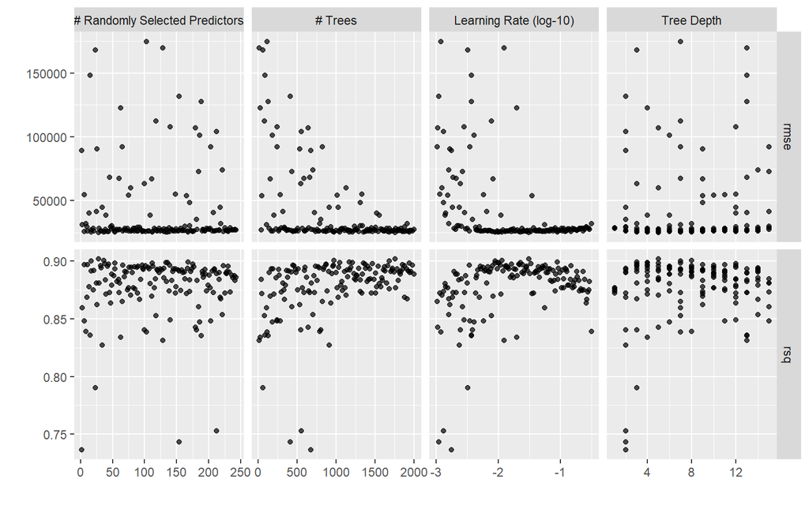

```r
autoplot(workflow_best_tuned)
```

```r
select_best(workflow_best_tuned, "rmse")
```

```
## # A tibble: 1 x 5
##    mtry trees tree_depth learn_rate .config
##   <int> <int>      <int>      <dbl> <chr>
## 1    28  1755          5     0.0312 Preprocessor1_Model017
```

**Fit the final model**

Now let’s test with the unseen **test data**

```r
workflow_best_final <- finalize_workflow(workflow_best, select_best(workflow_best_tuned, "rmse"))

doParallel::registerDoParallel()

workflow_best_final_fit <- workflow_best_final %>%
  last_fit(
    split = sales_split
  )
```

```
## ! train/test split: preprocessor 1/1: Non-positive values in selected variable., Fewer than `num_unique` value...
```

```r
doParallel::stopImplicitCluster()

workflow_best_final_fit
```

```
## # Resampling results
## # Manual resampling
## # A tibble: 1 x 6
##   splits             id               .metrics .notes   .predictions .workflow
##   <list>             <chr>            <list>   <list>   <list>       <list>
## 1 <split [1314/146]> train/test split <tibble> <tibble> <tibble>     <workflow>
##
## There were issues with some computations:
##
##   - Warning(s) x1: Non-positive values in selected variable., Fewer than `num_unique...
##
## Run `show_notes(.Last.tune.result)` for more information.
```

```r
workflow_best_final_fit %>%
  collect_metrics()
```

```
## # A tibble: 2 x 4
##   .metric .estimator .estimate .config
##   <chr>   <chr>          <dbl> <chr>
## 1 rmse    standard   24853.    Preprocessor1_Model1
## 2 rsq     standard       0.906 Preprocessor1_Model1
```

**R2 of 0.91**

**Some visualizations of the selected winner model**

```r
fit_test <- workflow_best_final_fit %>%
  collect_predictions()

fit_test
```

```
## # A tibble: 146 x 5
##    id                 .pred  .row SalePrice .config
##    <chr>              <dbl> <int>     <dbl> <chr>
##  1 train/test split 301319.     5    250000 Preprocessor1_Model1
##  2 train/test split 124986.    20    139000 Preprocessor1_Model1
##  3 train/test split 180091.    34    165500 Preprocessor1_Model1
##  4 train/test split 133426.    44    130250 Preprocessor1_Model1
##  5 train/test split 145016.    45    141000 Preprocessor1_Model1
##  6 train/test split 310751.    66    317000 Preprocessor1_Model1
##  7 train/test split 263161.    86    260000 Preprocessor1_Model1
##  8 train/test split 147370.    93    163500 Preprocessor1_Model1
##  9 train/test split 187506.    96    185000 Preprocessor1_Model1
## 10 train/test split 204675.   104    198900 Preprocessor1_Model1
## # ... with 136 more rows
```

**Plot our predictions vs actual unseen test data**

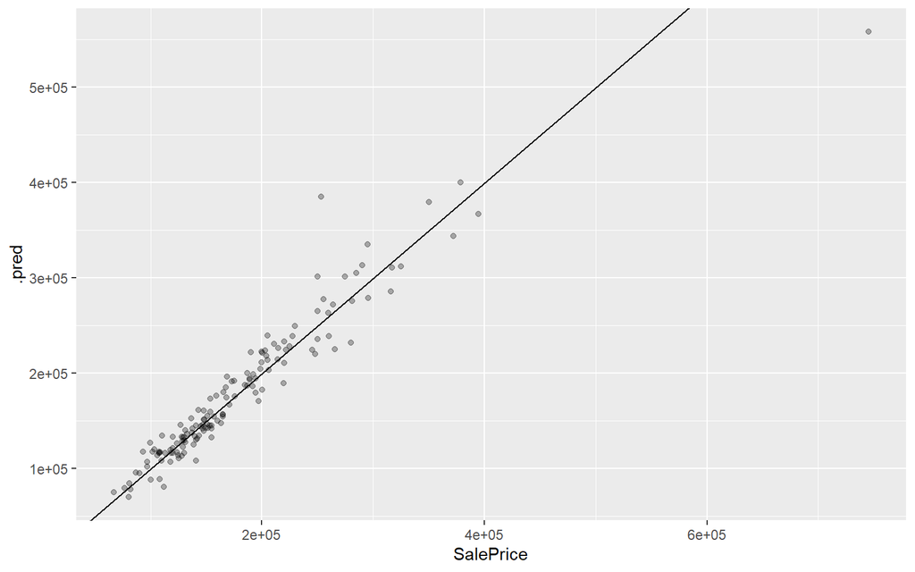

```r
fit_test %>%
  ggplot(aes(x=SalePrice, y=.pred)) +
  geom_abline(slope=1,intercept=0) +
  geom_point(alpha=0.3)
```

**Boxplot of predictions vs actual results**

```r
boxplot_data <- fit_test %>%
  mutate(difference = .pred - SalePrice)
```

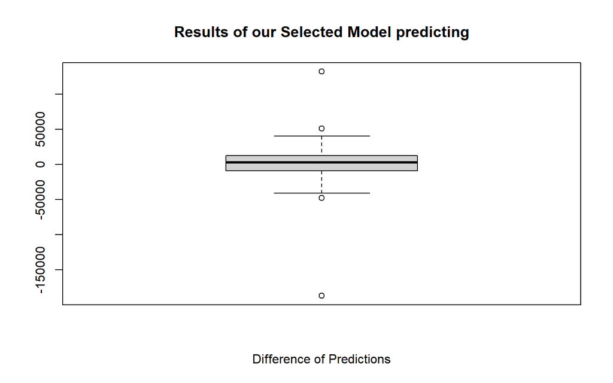

```r
boxplot_data$difference %>%
  boxplot(main = "Results of our Selected Model predicting",
          xlab = "Difference of Predictions",
          horizontal = FALSE)
```

### 3.10.10 Analysis of Regression Variables

**Variable Importance**

Here we use the **VIP** library which helps us identify the most important variables used in our selected model. This ranking of importance can help us explain our model. Here you will the most important variable ranked from the top.

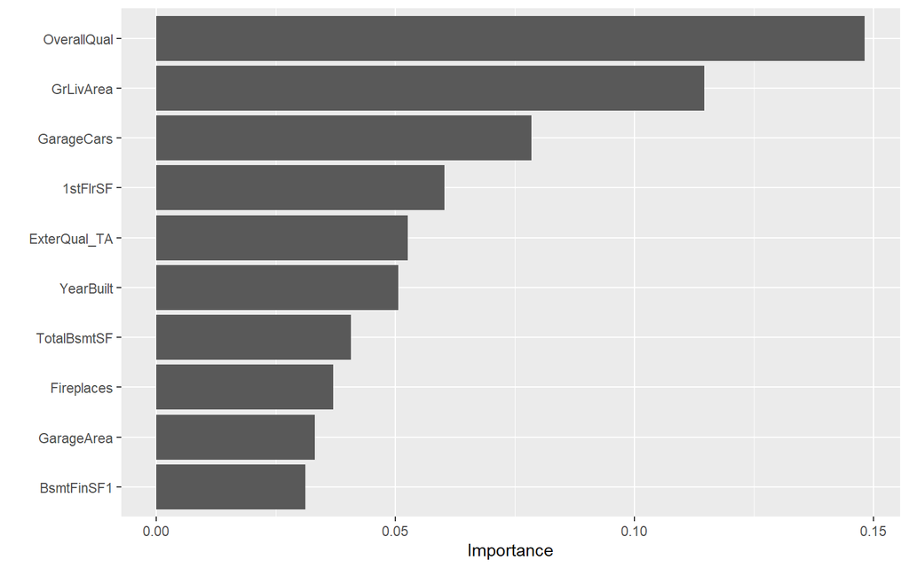

```r
library(vip)
extract_workflow(workflow_best_final_fit) %>%
  extract_fit_parsnip() %>%
  vip(geom = "col")
```

### 3.10.11 Predict on NEW DATA and load to KAGGLE

**KAGGLE username: juanfalck**

```r
my_predictions1 <- workflow_best_final_fit$.workflow[[1]] %>%
  predict(test_df)
```

**Save the data in .CSV file to upload to KAGGLE**

```r
my_predictions2 <- as_tibble(test_df$Id)
my_predictions2$pred <- my_predictions1$.pred
write.csv(my_predictions2,"JF_predictions.csv")
```

[figure not shown]

# THANK YOU!

**It has been a great class!!!**